# ML Modelos Supervisionados Clássicos

Projeto Final (1) - Spaceship Titanic

# Preparação Inicial

Definir diretório e pacotes necessários.

```r
load.pks = c(
  "readr",
  "ggplot2",
  "plotly",
  "e1071",
  "dplyr",
  "tidyr",
  "nortest",
  "gridExtra",
  "kableExtra",
  "visdat",
  "stringr",
  "mlbench",
  "caret",
  "GGally",
  "RColorBrewer",
  "ROCR",
  "pROC",
  "rmarkdown",
  "qqplotr",
  "reshape2",
  "ggfortify",
  "car",
  "vip",
  "MASS"
)

lapply(load.pks, require, character.only = TRUE)
```

# Spaceship Titanic

https://www.kaggle.com/competitions/spaceship-titanic/data

# Entendimento do Negócio [Business Understanding]

## Objetivo

O objetivo é prever se um passageiro foi transportado para uma dimensão alternativa durante a colisão da nave espacial Titanic com a anomalia do espaço-tempo.  
Para ajudá-lo a fazer essas previsões, você recebe um conjunto de registros pessoais recuperados do sistema de computador danificado da nave.

# Entendimento dos Dados [Data Understanding]

## Descrição das Variáveis

**train.csv** - Registros pessoais de cerca de dois terços (~8700) dos passageiros.

- *PassengerId* - Um ID exclusivo para cada passageiro. Cada ID assume o formato **gggg_pp**, onde:
  - **gggg** indica um grupo com o qual o passageiro está viajando e
  - **pp** é seu número dentro do grupo.  
    As pessoas em um grupo geralmente são membros da família, mas nem sempre.
- *HomePlanet* - O planeta de onde o passageiro partiu, normalmente seu planeta de residência permanente.
- *CryoSleep* - Indica se o passageiro optou por ser colocado em animação suspensa durante a viagem. Os passageiros em sono criogênico estão confinados em suas cabines.
- *Cabine* - O número da cabine onde o passageiro está hospedado. Assume o formato deck/num/side, onde o lado pode ser **P** para bombordo ou **S** para estibordo.
- *Destino* - O planeta para o qual o passageiro irá desembarcar.
- *Idade* - A idade do passageiro.
- *VIP* - Se o passageiro pagou pelo serviço VIP especial durante a viagem.
- *RoomService, FoodCourt, ShoppingMall, Spa, VRDeck* - Valor que o passageiro cobrou em cada uma das muitas comodidades de luxo da Spaceship Titanic.
- *Nome* - O nome e sobrenome do passageiro.
- *Transportado* - Se o passageiro foi transportado para outra dimensão. Este é o target, a coluna que você está tentando prever.  
  **test.csv** - Registros pessoais para o terço restante (~4300) dos passageiros, para serem usados como dados de teste.  
  Sua tarefa é prever o valor de Transportado para os passageiros neste conjunto.  
  **sample_submission.csv** - Um arquivo de envio no formato correto.
- *PassengerId* - Id para cada passageiro no conjunto de teste.
- *Transportado* - O alvo. Para cada passageiro, preveja *Verdadeiro* ou *Falso*.

# Preparação dos Dados [Data Preparation]

## Importação dos Dados

Vamos importar os 3 bancos: Train, Test e Sample_Submission.

```r
ds1_train <- read_csv(".\\spaceship-titanic\\train.csv")
ds1_test <- read_csv(".\\spaceship-titanic\\test.csv")
ds1_submission <- read_csv(".\\spaceship-titanic\\sample_submission.csv")
```

Antes de ajustar as variáveis, vamos combinar os dados para que as mudanças sejam feitas de forma mais rápida.

```r
#merge between test & submission
ds1_test_submission <- merge(ds1_test, ds1_submission, by=c("PassengerId", "PassengerId"))

ds1_train$table <- "train"
ds1_test_submission$table <- "test"

ds1_all <- rbind(ds1_train, ds1_test_submission)
```

## Ajuste das Variáveis

Separou-se a variável **PassengerId** em GroupID e QtyID.  
Separou-se a variável **Name** em Name_1 e Name_2.  
Separou-se a variável **Cabin** em Deck, Num_cab e Side.  
Transformação das variáveis binárias (True/False para 1/0): Transported, CyroSleep e VIP.

```r
ds1_all <- ds1_all %>%
  mutate(GroupID = as.factor(word(PassengerId, 1, sep="_")),
           QtyID = as.factor(word(PassengerId, 2, sep="_")),
          First_Name = as.factor(word(Name, 1, sep=" ")),
          Last_Name = as.factor(word(Name, 2, sep=" "))
         )

max_qty <- ds1_all %>%
  group_by(GroupID) %>%
  summarise(QtyID_max = max(
    as.numeric(word(PassengerId, 2, sep="_")), na.rm = TRUE)
    )

ds1_all <- left_join(ds1_all, max_qty,
              by = c("GroupID" = "GroupID"))

ds1_all <- ds1_all %>%
  mutate(Deck = as.factor(word(Cabin, 1, sep="/")),
         Num_cab = as.factor(word(Cabin, 2, sep="/")),
         Side = as.factor(word(Cabin, 3, sep="/"))
         )


ds1_all <- ds1_all %>%
  mutate(
    Transported_ = as.factor(case_when(
      Transported == "TRUE"  ~ 1,
      Transported == "FALSE" ~ 0
  ))
)

ds1_all <- ds1_all %>%
  mutate(
    CryoSleep_ = as.factor(case_when(
      CryoSleep == "TRUE"  ~ 1,
      CryoSleep == "FALSE" ~ 0
  ))
)

ds1_all <- ds1_all %>%
  mutate(
    VIP_ = as.factor(case_when(
      VIP == "TRUE"  ~ 1,
      VIP == "FALSE" ~ 0
  ))
)
```

Snapshot:

```r
head(ds1_all) %>%  kbl %>%  kable_paper(c("striped", "hover"), full_width = F, fixed_thead = T)
```

| PassengerId | HomePlanet | CryoSleep | Cabin | Destination | Age | VIP | RoomService | FoodCourt | ShoppingMall | Spa | VRDeck | Name | Transported | table | GroupID | QtyID | First_Name | Last_Name | QtyID_max | Deck | Num_cab | Side | Transported_ | CryoSleep_ | VIP_ |
| --- | --- | --- | --- | --- | --- | --- | --- | --- | --- | --- | --- | --- | --- | --- | --- | --- | --- | --- | --- | --- | --- | --- | --- | --- | --- |
| 0001_01 | Europa | FALSE | B/0/P | TRAPPIST-1e | 39 | FALSE | 0 | 0 | 0 | 0 | 0 | Maham Ofracculy | FALSE | train | 0001 | 01 | Maham | Ofracculy | 1 | B | 0 | P | 0 | 0 | 0 |
| 0002_01 | Earth | FALSE | F/0/S | TRAPPIST-1e | 24 | FALSE | 109 | 9 | 25 | 549 | 44 | Juanna Vines | TRUE | train | 0002 | 01 | Juanna | Vines | 1 | F | 0 | S | 1 | 0 | 0 |
| 0003_01 | Europa | FALSE | A/0/S | TRAPPIST-1e | 58 | TRUE | 43 | 3576 | 0 | 6715 | 49 | Altark Susent | FALSE | train | 0003 | 01 | Altark | Susent | 2 | A | 0 | S | 0 | 0 | 1 |
| 0003_02 | Europa | FALSE | A/0/S | TRAPPIST-1e | 33 | FALSE | 0 | 1283 | 371 | 3329 | 193 | Solam Susent | FALSE | train | 0003 | 02 | Solam | Susent | 2 | A | 0 | S | 0 | 0 | 0 |
| 0004_01 | Earth | FALSE | F/1/S | TRAPPIST-1e | 16 | FALSE | 303 | 70 | 151 | 565 | 2 | Willy Santantines | TRUE | train | 0004 | 01 | Willy | Santantines | 1 | F | 1 | S | 1 | 0 | 0 |
| 0005_01 | Earth | FALSE | F/0/P | PSO J318.5-22 | 44 | FALSE | 0 | 483 | 0 | 291 | 0 | Sandie Hinetthews | TRUE | train | 0005 | 01 | Sandie | Hinetthews | 1 | F | 0 | P | 1 | 0 | 0 |

## Resumo dos Dados

### Train

```r
train1_summary <- summary(ds1_all[ds1_all$table == "train",])

train1_summary %>%  kbl %>%  kable_paper(c("striped", "hover"), full_width = F, fixed_thead = T)
```

|  | PassengerId | HomePlanet | CryoSleep | Cabin | Destination | Age | VIP | RoomService | FoodCourt | ShoppingMall | Spa | VRDeck | Name | Transported | table | GroupID | QtyID | First_Name | Last_Name | QtyID_max | Deck | Num_cab | Side | Transported_ | CryoSleep_ | VIP_ |
| --- | --- | --- | --- | --- | --- | --- | --- | --- | --- | --- | --- | --- | --- | --- | --- | --- | --- | --- | --- | --- | --- | --- | --- | --- | --- | --- |
|  | Length:8693 | Length:8693 | Mode :logical | Length:8693 | Length:8693 | Min. : 0.00 | Mode :logical | Min. : 0.0 | Min. : 0.0 | Min. : 0.0 | Min. : 0.0 | Min. : 0.0 | Length:8693 | Mode :logical | Length:8693 | 0984 : 8 | 01 :6217 | Idace : 13 | Casonston : 18 | Min. :1.000 | F :2794 | 82 : 28 | P :4206 | 0:4315 | 0 :5439 | 0 :8291 |
|  | Class :character | Class :character | FALSE:5439 | Class :character | Class :character | 1st Qu.:19.00 | FALSE:8291 | 1st Qu.: 0.0 | 1st Qu.: 0.0 | 1st Qu.: 0.0 | 1st Qu.: 0.0 | 1st Qu.: 0.0 | Class :character | FALSE:4315 | Class :character | 4005 : 8 | 02 :1412 | Loree : 12 | Oneiles : 16 | 1st Qu.:1.000 | G :2559 | 19 : 22 | S :4288 | 1:4378 | 1 :3037 | 1 : 199 |
|  | Mode :character | Mode :character | TRUE :3037 | Mode :character | Mode :character | Median :27.00 | TRUE :199 | Median : 0.0 | Median : 0.0 | Median : 0.0 | Median : 0.0 | Median : 0.0 | Mode :character | TRUE :4378 | Mode :character | 4256 : 8 | 03 : 571 | Dandra : 11 | Domington : 15 | Median :1.000 | E : 876 | 86 : 22 | NA’s: 199 | NA | NA’s: 217 | NA’s: 203 |
|  | NA | NA | NA’s :217 | NA | NA | Mean :28.83 | NA’s :203 | Mean : 224.7 | Mean : 458.1 | Mean : 173.7 | Mean : 311.1 | Mean : 304.9 | NA | NA | NA | 4498 : 8 | 04 : 231 | Glena : 11 | Litthews : 15 | Mean :2.036 | B : 779 | 176 : 21 | NA | NA | NA | NA |
|  | NA | NA | NA | NA | NA | 3rd Qu.:38.00 | NA | 3rd Qu.: 47.0 | 3rd Qu.: 76.0 | 3rd Qu.: 27.0 | 3rd Qu.: 59.0 | 3rd Qu.: 46.0 | NA | NA | NA | 5133 : 8 | 05 : 128 | Gwendy : 11 | Browlerson: 14 | 3rd Qu.:3.000 | C : 747 | 56 : 21 | NA | NA | NA | NA |
|  | NA | NA | NA | NA | NA | Max. :79.00 | NA | Max. :14327.0 | Max. :29813.0 | Max. :23492.0 | Max. :22408.0 | Max. :24133.0 | NA | NA | NA | 5756 : 8 | 06 : 75 | (Other):8435 | (Other) :8415 | Max. :8.000 | (Other): 739 | (Other):8380 | NA | NA | NA | NA |
|  | NA | NA | NA | NA | NA | NA’s :179 | NA | NA’s :181 | NA’s :183 | NA’s :208 | NA’s :183 | NA’s :188 | NA | NA | NA | (Other):8645 | (Other): 59 | NA’s : 200 | NA’s : 200 | NA | NA’s : 199 | NA’s : 199 | NA | NA | NA | NA |

```r
train1_summary2 <- ds1_all[ds1_all$table == "train",] %>%
  dplyr::select(Transported_) %>%
  summarise(
    n_train = n()
  )
```

Notamos que algumas das variáveis possuem valores faltantes:

- PassengerId: 0 que representa 0%
- HomePlanet: 201 que representa 2.3%
- CyroSleep: 217 que representa 2.5%
- Cabin: 199 que representa 2.3%
- Destination: 182 que representa 2.1%
- Age: 179 que representa 2.1%
- VIP: 203 que representa 2.3%
- RoomService: 181 que representa 2.1%
- FoodCourt: 183 que representa 2.1%
- ShoppingMall: 208 que representa 2.4%
- SPA: 183 que representa 2.1%
- VRDeck: 188 que representa 2.2%
- Name: 200 que representa 2.3%
- Transported: 0 que representa 0%

### Test

```r
test1_summary <- summary(ds1_all[ds1_all$table == "test",])

test1_summary %>%  kbl %>%  kable_paper(c("striped", "hover"), full_width = F, fixed_thead = T)
```

|  | PassengerId | HomePlanet | CryoSleep | Cabin | Destination | Age | VIP | RoomService | FoodCourt | ShoppingMall | Spa | VRDeck | Name | Transported | table | GroupID | QtyID | First_Name | Last_Name | QtyID_max | Deck | Num_cab | Side | Transported_ | CryoSleep_ | VIP_ |
| --- | --- | --- | --- | --- | --- | --- | --- | --- | --- | --- | --- | --- | --- | --- | --- | --- | --- | --- | --- | --- | --- | --- | --- | --- | --- | --- |
|  | Length:4277 | Length:4277 | Mode :logical | Length:4277 | Length:4277 | Min. : 0.00 | Mode :logical | Min. : 0.0 | Min. : 0.0 | Min. : 0.0 | Min. : 0.0 | Min. : 0.0 | Length:4277 | Mode :logical | Length:4277 | 0339 : 8 | 01 :3063 | Evendy : 9 | Extraly : 14 | Min. :1.000 | F :1445 | 4 : 21 | P :2084 | 0:4277 | 0 :2640 | 0 :4110 |
|  | Class :character | Class :character | FALSE:2640 | Class :character | Class :character | 1st Qu.:19.00 | FALSE:4110 | 1st Qu.: 0.0 | 1st Qu.: 0.0 | 1st Qu.: 0.0 | 1st Qu.: 0.0 | 1st Qu.: 0.0 | Class :character | FALSE:4277 | Class :character | 1072 : 8 | 02 : 723 | Rankie : 8 | Hopperett : 13 | 1st Qu.:1.000 | G :1222 | 31 : 18 | S :2093 | 1: 0 | 1 :1544 | 1 : 74 |
|  | Mode :character | Mode :character | TRUE :1544 | Mode :character | Mode :character | Median :26.00 | TRUE :74 | Median : 0.0 | Median : 0.0 | Median : 0.0 | Median : 0.0 | Median : 0.0 | Mode :character | NA | Mode :character | 6332 : 8 | 03 : 269 | Geneen : 7 | Tranklinay: 11 | Median :1.000 | E : 447 | 197 : 16 | NA’s: 100 | NA | NA’s: 93 | NA’s: 93 |
|  | NA | NA | NA’s :93 | NA | NA | Mean :28.66 | NA’s :93 | Mean : 219.3 | Mean : 439.5 | Mean : 177.3 | Mean : 303.1 | Mean : 310.7 | NA | NA | NA | 6499 : 8 | 04 : 107 | Gerly : 7 | Dickley : 10 | Mean :1.997 | B : 362 | 294 : 16 | NA | NA | NA | NA |
|  | NA | NA | NA | NA | NA | 3rd Qu.:37.00 | NA | 3rd Qu.: 53.0 | 3rd Qu.: 78.0 | 3rd Qu.: 33.0 | 3rd Qu.: 50.0 | 3rd Qu.: 36.0 | NA | NA | NA | 6986 : 8 | 05 : 56 | Kirky : 7 | Garrez : 10 | 3rd Qu.:2.000 | C : 355 | 228 : 14 | NA | NA | NA | NA |
|  | NA | NA | NA | NA | NA | Max. :79.00 | NA | Max. :11567.0 | Max. :25273.0 | Max. :8292.0 | Max. :19844.0 | Max. :22272.0 | NA | NA | NA | 8543 : 8 | 06 : 33 | (Other):4145 | (Other) :4125 | Max. :8.000 | (Other): 346 | (Other):4092 | NA | NA | NA | NA |
|  | NA | NA | NA | NA | NA | NA’s :91 | NA | NA’s :82 | NA’s :106 | NA’s :98 | NA’s :101 | NA’s :80 | NA | NA | NA | (Other):4229 | (Other): 26 | NA’s : 94 | NA’s : 94 | NA | NA’s : 100 | NA’s : 100 | NA | NA | NA | NA |

```r
test1_summary2 <- ds1_all[ds1_all$table == "test",] %>%
  dplyr::select(CryoSleep_) %>%
  summarise(
    n_test = n()
  )
```

Notamos que algumas das variáveis possuem valores faltantes:

- PassengerId: 0 que representa 0%
- HomePlanet: 87 que representa 2%
- CyroSleep: 93 que representa 2.2%
- Cabin: 100 que representa 2.3%
- Destination: 92 que representa 2.2%
- Age: 91 que representa 2.1%
- VIP: 93 que representa 2.2%
- RoomService: 82 que representa 1.9%
- FoodCourt: 106 que representa 2.5%
- ShoppingMall: 98 que representa 2.3%
- SPA: 101 que representa 2.4%
- VRDeck: 80 que representa 1.9%
- Name: 94 que representa 2.2%

## Valores Faltantes

Podemos tentar fazer a análise de duas maneiras distintas, ou remover todos os valores faltantes de todas as variáveis, ou atribuir valores distintos, para que se tenha uma análise diferenciada desse grupo.

### Remover completamente

Eliminar completamente os valores faltantes da base.

```r
ds1_all2 <- na.omit(ds1_all)

ds1_all2$Total_Spend <- ds1_all2$RoomService +
                              ds1_all2$FoodCourt +
                              ds1_all2$ShoppingMall +
                              ds1_all2$Spa +
                              ds1_all2$VRDeck
```

### Summary

#### Train

```r
train2_summary <- summary(ds1_all2[ds1_all2$table == "train", ])

train2_summary %>%  kbl %>%  kable_paper(c("striped", "hover"), full_width = F, fixed_thead = T)
```

|  | PassengerId | HomePlanet | CryoSleep | Cabin | Destination | Age | VIP | RoomService | FoodCourt | ShoppingMall | Spa | VRDeck | Name | Transported | table | GroupID | QtyID | First_Name | Last_Name | QtyID_max | Deck | Num_cab | Side | Transported_ | CryoSleep_ | VIP_ | Total_Spend |
| --- | --- | --- | --- | --- | --- | --- | --- | --- | --- | --- | --- | --- | --- | --- | --- | --- | --- | --- | --- | --- | --- | --- | --- | --- | --- | --- | --- |
|  | Length:6606 | Length:6606 | Mode :logical | Length:6606 | Length:6606 | Min. : 0.00 | Mode :logical | Min. : 0 | Min. : 0.00 | Min. : 0.0 | Min. : 0.0 | Min. : 0.0 | Length:6606 | Mode :logical | Length:6606 | 4256 : 8 | 01 :4734 | Gwendy : 10 | Casonston: 17 | Min. :1.000 | F :2152 | 82 : 22 | P:3261 | 0:3279 | 0:4274 | 0:6444 | Min. : 0 |
|  | Class :character | Class :character | FALSE:4274 | Class :character | Class :character | 1st Qu.:19.00 | FALSE:6444 | 1st Qu.: 0 | 1st Qu.: 0.00 | 1st Qu.: 0.0 | 1st Qu.: 0.0 | 1st Qu.: 0.0 | Class :character | FALSE:3279 | Class :character | 0221 : 7 | 02 :1062 | Kaye : 10 | Oneiles : 15 | 1st Qu.:1.000 | G :1973 | 56 : 19 | S:3345 | 1:3327 | 1:2332 | 1: 162 | 1st Qu.: 0 |
|  | Mode :character | Mode :character | TRUE :2332 | Mode :character | Mode :character | Median :27.00 | TRUE :162 | Median : 0 | Median : 0.00 | Median : 0.0 | Median : 0.0 | Median : 0.0 | Mode :character | TRUE :3327 | Mode :character | 0378 : 7 | 03 : 432 | Leneva : 10 | Domington: 13 | Median :1.000 | E : 683 | 97 : 19 | NA | NA | NA | NA | Median : 739 |
|  | NA | NA | NA | NA | NA | Mean :28.89 | NA | Mean : 223 | Mean : 478.96 | Mean : 178.4 | Mean : 313.2 | Mean : 303.8 | NA | NA | NA | 3850 : 7 | 04 : 178 | Benry : 9 | Garnes : 13 | Mean :2.031 | B : 628 | 176 : 18 | NA | NA | NA | NA | Mean : 1497 |
|  | NA | NA | NA | NA | NA | 3rd Qu.:38.00 | NA | 3rd Qu.: 49 | 3rd Qu.: 82.75 | 3rd Qu.: 30.0 | 3rd Qu.: 65.0 | 3rd Qu.: 52.0 | NA | NA | NA | 4176 : 7 | 05 : 99 | Eulah : 9 | Litthews : 13 | 3rd Qu.:3.000 | C : 587 | 186 : 17 | NA | NA | NA | NA | 3rd Qu.: 1514 |
|  | NA | NA | NA | NA | NA | Max. :79.00 | NA | Max. :9920 | Max. :29813.00 | Max. :12253.0 | Max. :22408.0 | Max. :20336.0 | NA | NA | NA | 4498 : 7 | 06 : 60 | Jerrye : 9 | Briggston: 12 | Max. :8.000 | D : 374 | 269 : 17 | NA | NA | NA | NA | Max. :35987 |
|  | NA | NA | NA | NA | NA | NA | NA | NA | NA | NA | NA | NA | NA | NA | NA | (Other):6563 | (Other): 41 | (Other):6549 | (Other) :6523 | NA | (Other): 209 | (Other):6494 | NA | NA | NA | NA | NA |

```r
train2_summary2 <- ds1_all2[ds1_all2$table == "train", ] %>%
  dplyr::select(CryoSleep_) %>%
  summarise(
    n_test = n()
  )
```

#### Test

```r
test2_summary <- summary(ds1_all2[ds1_all2$table == "test", ])

test2_summary %>%  kbl %>% kable_paper(c("striped", "hover"), full_width = F, fixed_thead = T)
```

|  | PassengerId | HomePlanet | CryoSleep | Cabin | Destination | Age | VIP | RoomService | FoodCourt | ShoppingMall | Spa | VRDeck | Name | Transported | table | GroupID | QtyID | First_Name | Last_Name | QtyID_max | Deck | Num_cab | Side | Transported_ | CryoSleep_ | VIP_ | Total_Spend |
| --- | --- | --- | --- | --- | --- | --- | --- | --- | --- | --- | --- | --- | --- | --- | --- | --- | --- | --- | --- | --- | --- | --- | --- | --- | --- | --- | --- |
|  | Length:3281 | Length:3281 | Mode :logical | Length:3281 | Length:3281 | Min. : 0.00 | Mode :logical | Min. : 0.0 | Min. : 0.0 | Min. : 0.0 | Min. : 0.0 | Min. : 0.0 | Length:3281 | Mode :logical | Length:3281 | 6986 : 8 | 01 :2353 | Luise : 7 | Hopperett : 12 | Min. :1.000 | F :1158 | 4 : 19 | P:1637 | 0:3281 | 0:2065 | 0:3223 | Min. : 0 |
|  | Class :character | Class :character | FALSE:2065 | Class :character | Class :character | 1st Qu.:19.00 | FALSE:3223 | 1st Qu.: 0.0 | 1st Qu.: 0.0 | 1st Qu.: 0.0 | 1st Qu.: 0.0 | 1st Qu.: 0.0 | Class :character | FALSE:3281 | Class :character | 0339 : 7 | 02 : 550 | Naomie : 7 | Extraly : 11 | 1st Qu.:1.000 | G : 938 | 34 : 13 | S:1644 | 1: 0 | 1:1216 | 1: 58 | 1st Qu.: 0 |
|  | Mode :character | Mode :character | TRUE :1216 | Mode :character | Mode :character | Median :26.00 | TRUE :58 | Median : 0.0 | Median : 0.0 | Median : 0.0 | Median : 0.0 | Median : 0.0 | Mode :character | NA | Mode :character | 1354 : 7 | 03 : 204 | Rankie : 7 | Barnolderg: 9 | Median :1.000 | E : 348 | 184 : 12 | NA | NA | NA | NA | Median : 720 |
|  | NA | NA | NA | NA | NA | Mean :28.58 | NA | Mean : 220.1 | Mean : 440.9 | Mean : 175.3 | Mean : 296.7 | Mean : 300.4 | NA | NA | NA | 3601 : 7 | 04 : 87 | Dawne : 6 | Garrez : 9 | Mean :1.989 | B : 283 | 31 : 12 | NA | NA | NA | NA | Mean : 1433 |
|  | NA | NA | NA | NA | NA | 3rd Qu.:37.00 | NA | 3rd Qu.: 53.0 | 3rd Qu.: 78.0 | 3rd Qu.: 27.0 | 3rd Qu.: 49.0 | 3rd Qu.: 34.0 | NA | NA | NA | 3659 : 7 | 05 : 36 | Dellia : 6 | Barris : 7 | 3rd Qu.:2.000 | C : 278 | 41 : 12 | NA | NA | NA | NA | 3rd Qu.: 1449 |
|  | NA | NA | NA | NA | NA | Max. :79.00 | NA | Max. :11567.0 | Max. :20809.0 | Max. :8292.0 | Max. :15733.0 | Max. :19086.0 | NA | NA | NA | 0775 : 6 | 06 : 30 | Doryn : 6 | Belley : 7 | Max. :8.000 | D : 194 | 7 : 12 | NA | NA | NA | NA | Max. :33666 |
|  | NA | NA | NA | NA | NA | NA | NA | NA | NA | NA | NA | NA | NA | NA | NA | (Other):3239 | (Other): 21 | (Other):3242 | (Other) :3226 | NA | (Other): 82 | (Other):3201 | NA | NA | NA | NA | NA |

```r
test2_summary2 <- ds1_all2[ds1_all2$table == "test", ] %>%
  dplyr::select(CryoSleep_) %>%
  summarise(
    n_test = n()
  )
```

### Atribuir valores distintos

Ao invés de remover os valores faltantes vamos atribuir valores diferentes do restante.  
Para as variáveis qualitativas como *HomePlanet*, *CryoSleep*, *Cabin*, *Destination* e *Name* para os valores faltantes vamos atribuir **“Not Defined”**.  
Para as variáveis qualitativas como *Deck* e *Side*, vamos usar **“Z”** para os valores faltantes.  
Para a variável quantitativa que indica o número da cabine *Num_cab*, atribuímos o número **9999** onde o valor estava faltando.  
Para as variáveis quantitativas contínuas como *Age*, *RoomService*, *FoodCourt*, *ShoppingMall*, *SPA* e *VRDeck*, decidiu-se por inserir o valor mediano do grupo em que essa variável fantante se encontrava. Caso a variável faltante não tenha nenhum valor dentro do grupo atribuiu-se o valor mediano geral da base.

#### Train

```r
#Variáveis qualitativas
ds1_all3 <- ds1_all
ds1_all3$HomePlanet <- ifelse(is.na(ds1_all3$HomePlanet), "Not Defined", ds1_all3$HomePlanet)
ds1_all3$CryoSleep <- ifelse(is.na(ds1_all3$CryoSleep), "Not Defined" , ds1_all3$CryoSleep)
ds1_all3$CryoSleep_ <- ifelse(is.na(ds1_all3$CryoSleep_), 9 , ds1_all3$CryoSleep_)
ds1_all3$Cabin <- ifelse(is.na(ds1_all3$Cabin), "Not Defined" , ds1_all3$Cabin)
ds1_all3$Deck <- ifelse(is.na(ds1_all3$Deck), "Z" , ds1_all3$Deck)
ds1_all3$Side <- ifelse(is.na(ds1_all3$Side), "Z" , ds1_all3$Side)
ds1_all3$Destination <- ifelse(is.na(ds1_all3$Destination), "Not Defined" , ds1_all3$Destination)
ds1_all3$Name <- ifelse(is.na(ds1_all3$Name), "Not Defined" , ds1_all3$Name)

#Número da Cabine
# max(unique(as.numeric(ds1_all3$Num_cab)), na.rm = TRUE) # numero mais alto de cabine
ds1_all3$Num_cab <- ifelse(is.na(ds1_all3$Num_cab), 9999 , ds1_all3$Num_cab)

## TRAIN
#Variáveis quantitativas
# median by GroupID
na_bygroup_train <- ds1_all[ds1_all$table == "train",] %>%
  dplyr::select(GroupID, QtyID_max, QtyID, Age, RoomService, FoodCourt, ShoppingMall, Spa, VRDeck) %>%
  group_by(GroupID) %>%
  summarise(
    QtyID_x_g = max(as.numeric(QtyID), na.rm=TRUE),
    Age_na_g = median(Age, na.rm=TRUE),
    RoomService_na_g = median(RoomService, na.rm=TRUE),
    FoodCourt_na_g = median(FoodCourt, na.rm=TRUE),
    ShoppingMall_na_g = median(ShoppingMall, na.rm=TRUE),
    Spa_na_g = median(Spa, na.rm=TRUE),
    VRDeck_na_g = median(VRDeck, na.rm=TRUE)
  )

#na_bygroup_train %>%  kbl %>% kable_paper("hover", full_width = F)

# Median overall
na_train <- ds1_all[ds1_all$table == "train",] %>%
  dplyr::select(Age, RoomService, FoodCourt, ShoppingMall, Spa, VRDeck) %>%
  summarise(
    Age_na = median(Age, na.rm=TRUE),
    RoomService_na = median(RoomService, na.rm=TRUE),
    FoodCourt_na = median(FoodCourt, na.rm=TRUE),
    ShoppingMall_na = median(ShoppingMall, na.rm=TRUE),
    Spa_na = median(Spa, na.rm=TRUE),
    VRDeck_na = median(VRDeck, na.rm=TRUE)
  )

#na_train %>%  kbl %>% kable_paper("hover", full_width = F)

# Mean overall
na_train_mean <- ds1_all[ds1_all$table == "train",] %>%
  dplyr::select(Age, RoomService, FoodCourt, ShoppingMall, Spa, VRDeck) %>%
  summarise(
    Age_na = mean(Age, na.rm=TRUE),
    RoomService_na = mean(RoomService, na.rm=TRUE),
    FoodCourt_na = mean(FoodCourt, na.rm=TRUE),
    ShoppingMall_na = mean(ShoppingMall, na.rm=TRUE),
    Spa_na = mean(Spa, na.rm=TRUE),
    VRDeck_na = mean(VRDeck, na.rm=TRUE)
  )

#na_train_mean %>%  kbl %>% kable_paper("hover", full_width = F)

## TEST
#Variáveis quantitativas
# median by GroupID
na_bygroup_test <- ds1_all[ds1_all$table == "test",] %>%
  dplyr::select(GroupID, QtyID_max, QtyID, Age, RoomService, FoodCourt, ShoppingMall, Spa, VRDeck) %>%
  group_by(GroupID) %>%
  summarise(
    QtyID_x_g = max(as.numeric(QtyID), na.rm=TRUE),
    Age_na_g = median(Age, na.rm=TRUE),
    RoomService_na_g = median(RoomService, na.rm=TRUE),
    FoodCourt_na_g = median(FoodCourt, na.rm=TRUE),
    ShoppingMall_na_g = median(ShoppingMall, na.rm=TRUE),
    Spa_na_g = median(Spa, na.rm=TRUE),
    VRDeck_na_g = median(VRDeck, na.rm=TRUE)
  )

#na_bygroup_test %>%  kbl %>% kable_paper("hover", full_width = F)

# Median overall
na_test <- ds1_all[ds1_all$table == "test",] %>%
  dplyr::select(Age, RoomService, FoodCourt, ShoppingMall, Spa, VRDeck) %>%
  summarise(
    Age_na = median(Age, na.rm=TRUE),
    RoomService_na = median(RoomService, na.rm=TRUE),
    FoodCourt_na = median(FoodCourt, na.rm=TRUE),
    ShoppingMall_na = median(ShoppingMall, na.rm=TRUE),
    Spa_na = median(Spa, na.rm=TRUE),
    VRDeck_na = median(VRDeck, na.rm=TRUE)
  )

#na_test %>%  kbl %>% kable_paper("hover", full_width = F)

# Mean overall
na_test_mean <- ds1_all[ds1_all$table == "test",] %>%
  dplyr::select(Age, RoomService, FoodCourt, ShoppingMall, Spa, VRDeck) %>%
  summarise(
    Age_na = mean(Age, na.rm=TRUE),
    RoomService_na = mean(RoomService, na.rm=TRUE),
    FoodCourt_na = mean(FoodCourt, na.rm=TRUE),
    ShoppingMall_na = mean(ShoppingMall, na.rm=TRUE),
    Spa_na = mean(Spa, na.rm=TRUE),
    VRDeck_na = mean(VRDeck, na.rm=TRUE)
  )

#na_test_mean %>%  kbl %>% kable_paper("hover", full_width = F)
```

Inserindo as colunas calculadas na base.

```r
ds1_all3_train <- left_join(ds1_all3[ds1_all3$table == "train",], na_bygroup_train,
                        by = c("GroupID" = "GroupID"),
                        suffix = c("",""))

ds1_all3_train <- cbind(ds1_all3_train, na_train)
```

```r
ds1_all3_test <- left_join(ds1_all3[ds1_all3$table == "test",], na_bygroup_test,
                        by = c("GroupID" = "GroupID"),
                        suffix = c("",""))

ds1_all3_test <- cbind(ds1_all3_test, na_test)
```

Modificando os valores faltantes:

#### Train

```r
ds1_all3_train$Age <- ifelse(is.na(ds1_all3_train$Age),
                           ifelse(!is.na(ds1_all3_train$Age_na_g),
                                  ds1_all3_train$Age_na_g,
                                  ds1_all3_train$Age_na),
                           ds1_all3_train$Age)

ds1_all3_train$RoomService <- ifelse(is.na(ds1_all3_train$RoomService),
                                  ifelse(!is.na(ds1_all3_train$RoomService_na_g),
                                         ds1_all3_train$RoomService_na_g,
                                         ds1_all3_train$RoomService_na),
                                  ds1_all3_train$RoomService)

ds1_all3_train$FoodCourt <- ifelse(is.na(ds1_all3_train$FoodCourt),
                                ifelse(!is.na(ds1_all3_train$FoodCourt_na_g),
                                       ds1_all3_train$FoodCourt_na_g,
                                       ds1_all3_train$FoodCourt_na),
                                ds1_all3_train$FoodCourt)

ds1_all3_train$ShoppingMall <- ifelse(is.na(ds1_all3_train$ShoppingMall),
                                   ifelse(!is.na(ds1_all3_train$ShoppingMall_na_g),
                                          ds1_all3_train$ShoppingMall_na_g,
                                          ds1_all3_train$ShoppingMall_na),
                                   ds1_all3_train$ShoppingMall)

ds1_all3_train$Spa <- ifelse(is.na(ds1_all3_train$Spa),
                           ifelse(!is.na(ds1_all3_train$Spa_na_g),
                                  ds1_all3_train$Spa_na_g,
                                  ds1_all3_train$Spa_na),
                           ds1_all3_train$Spa)

ds1_all3_train$VRDeck <- ifelse(is.na(ds1_all3_train$VRDeck),
                             ifelse(!is.na(ds1_all3_train$VRDeck_na_g),
                                    ds1_all3_train$VRDeck_na_g,
                                    ds1_all3_train$VRDeck_na),
                             ds1_all3_train$VRDeck)

ds1_all3_train$Total_Spend <- ds1_all3_train$RoomService +
                              ds1_all3_train$FoodCourt +
                              ds1_all3_train$ShoppingMall +
                              ds1_all3_train$Spa +
                              ds1_all3_train$VRDeck
```

#### Test

```r
ds1_all3_test$Age <- ifelse(is.na(ds1_all3_test$Age),
                           ifelse(!is.na(ds1_all3_test$Age_na_g),
                                  ds1_all3_test$Age_na_g,
                                  ds1_all3_test$Age_na),
                           ds1_all3_test$Age)

ds1_all3_test$RoomService <- ifelse(is.na(ds1_all3_test$RoomService),
                                  ifelse(!is.na(ds1_all3_test$RoomService_na_g),
                                         ds1_all3_test$RoomService_na_g,
                                         ds1_all3_test$RoomService_na),
                                  ds1_all3_test$RoomService)

ds1_all3_test$FoodCourt <- ifelse(is.na(ds1_all3_test$FoodCourt),
                                ifelse(!is.na(ds1_all3_test$FoodCourt_na_g),
                                       ds1_all3_test$FoodCourt_na_g,
                                       ds1_all3_test$FoodCourt_na),
                                ds1_all3_test$FoodCourt)

ds1_all3_test$ShoppingMall <- ifelse(is.na(ds1_all3_test$ShoppingMall),
                                   ifelse(!is.na(ds1_all3_test$ShoppingMall_na_g),
                                          ds1_all3_test$ShoppingMall_na_g,
                                          ds1_all3_test$ShoppingMall_na),
                                   ds1_all3_test$ShoppingMall)

ds1_all3_test$Spa <- ifelse(is.na(ds1_all3_test$Spa),
                           ifelse(!is.na(ds1_all3_test$Spa_na_g),
                                  ds1_all3_test$Spa_na_g,
                                  ds1_all3_test$Spa_na),
                           ds1_all3_test$Spa)

ds1_all3_test$VRDeck <- ifelse(is.na(ds1_all3_test$VRDeck),
                             ifelse(!is.na(ds1_all3_test$VRDeck_na_g),
                                    ds1_all3_test$VRDeck_na_g,
                                    ds1_all3_test$VRDeck_na),
                             ds1_all3_test$VRDeck)

ds1_all3_test$Total_Spend <- ds1_all3_test$RoomService +
                              ds1_all3_test$FoodCourt +
                              ds1_all3_test$ShoppingMall +
                              ds1_all3_test$Spa +
                              ds1_all3_test$VRDeck
```

### Summary

#### Train

```r
train3_summary <- summary(ds1_all3_train)

train3_summary %>%  kbl %>%  kable_paper(c("striped", "hover"), full_width = F, fixed_thead = T)
```

|  | PassengerId | HomePlanet | CryoSleep | Cabin | Destination | Age | VIP | RoomService | FoodCourt | ShoppingMall | Spa | VRDeck | Name | Transported | table | GroupID | QtyID | First_Name | Last_Name | QtyID_max | Deck | Num_cab | Side | Transported_ | CryoSleep_ | VIP_ | QtyID_x_g | Age_na_g | RoomService_na_g | … |
| --- | --- | --- | --- | --- | --- | --- | --- | --- | --- | --- | --- | --- | --- | --- | --- | --- | --- | --- | --- | --- | --- | --- | --- | --- | --- | --- | --- | --- | --- | --- |
|  | Length:8693 | Length:8693 | Length:8693 | Length:8693 | Length:8693 | Min. : 0.00 | Mode :logical | Min. : 0 | Min. : 0.0 | Min. : 0.0 | Min. : 0 | Min. : 0 | Length:8693 | Mode :logical | Length:8693 | 0984 : 8 | 01 :6217 | Idace : 13 | Casonston : 18 | Min. :1.000 | Length:8693 | Min. : 1 | Length:8693 | 0:4315 | Min. :1.000 | 0 :8291 | Min. :1.000 | Min. : 0.00 | Min. : 0.0 | … |
|  | Class :character | Class :character | Class :character | Class :character | Class :character | 1st Qu.:19.00 | FALSE:8291 | 1st Qu.: 0 | 1st Qu.: 0.0 | 1st Qu.: 0.0 | 1st Qu.: 0 | 1st Qu.: 0 | Class :character | FALSE:4315 | Class :character | 4005 : 8 | 02 :1412 | Loree : 12 | Oneiles : 16 | 1st Qu.:1.000 | Class :character | 1st Qu.: 532 | Class :character | 1:4378 | 1st Qu.:1.000 | 1 : 199 | 1st Qu.:1.000 | 1st Qu.:20.00 | 1st Qu.: 0.0 | … |
|  | Mode :character | Mode :character | Mode :character | Mode :character | Mode :character | Median :27.00 | TRUE :199 | Median : 0 | Median : 0.0 | Median : 0.0 | Median : 0 | Median : 0 | Mode :character | TRUE :4378 | Mode :character | 4256 : 8 | 03 : 571 | Dandra : 11 | Domington : 15 | Median :1.000 | Mode :character | Median :1085 | Mode :character | NA | Median :1.000 | NA’s: 203 | Median :1.000 | Median :27.00 | Median : 0.0 | … |
|  | NA | NA | NA | NA | NA | Mean :28.78 | NA’s :203 | Mean : 222 | Mean : 451.5 | Mean : 170.4 | Mean : 307 | Mean : 302 | NA | NA | NA | 4498 : 8 | 04 : 231 | Glena : 11 | Litthews : 15 | Mean :2.036 | NA | Mean :1205 | NA | NA | Mean :1.549 | NA | Mean :2.036 | Mean :28.29 | Mean : 197.3 | … |
|  | NA | NA | NA | NA | NA | 3rd Qu.:37.00 | NA | 3rd Qu.: 43 | 3rd Qu.: 67.0 | 3rd Qu.: 23.0 | 3rd Qu.: 56 | 3rd Qu.: 41 | NA | NA | NA | 5133 : 8 | 05 : 128 | Gwendy : 11 | Browlerson: 14 | 3rd Qu.:3.000 | NA | 3rd Qu.:1439 | NA | NA | 3rd Qu.:2.000 | NA | 3rd Qu.:3.000 | 3rd Qu.:36.00 | 3rd Qu.: 60.0 | … |
|  | NA | NA | NA | NA | NA | Max. :79.00 | NA | Max. :14327 | Max. :29813.0 | Max. :23492.0 | Max. :22408 | Max. :24133 | NA | NA | NA | 5756 : 8 | 06 : 75 | (Other):8435 | (Other) :8415 | Max. :8.000 | NA | Max. :9999 | NA | NA | Max. :9.000 | NA | Max. :8.000 | Max. :79.00 | Max. :9920.0 | … |
|  | NA | NA | NA | NA | NA | NA | NA | NA | NA | NA | NA | NA | NA | NA | NA | (Other):8645 | (Other): 59 | NA’s : 200 | NA’s : 200 | NA | NA | NA | NA | NA | NA | NA | NA | NA’s :97 | NA’s :109 | … |

```r
train3_summary2 <- ds1_all3_train %>%
  dplyr::select(CryoSleep_) %>%
  summarise(
    n_test = n()
  )
```

#### Test

```r
test3_summary <- summary(ds1_all3_test)

test3_summary %>%  kbl %>%  kable_paper(c("striped", "hover"), full_width = F, fixed_thead = T)
```

|  | PassengerId | HomePlanet | CryoSleep | Cabin | Destination | Age | VIP | RoomService | FoodCourt | ShoppingMall | Spa | VRDeck | Name | Transported | table | GroupID | QtyID | First_Name | Last_Name | QtyID_max | Deck | Num_cab | Side | Transported_ | CryoSleep_ | VIP_ | QtyID_x_g | Age_na_g | RoomService_na_g | … |
| --- | --- | --- | --- | --- | --- | --- | --- | --- | --- | --- | --- | --- | --- | --- | --- | --- | --- | --- | --- | --- | --- | --- | --- | --- | --- | --- | --- | --- | --- | --- |
|  | Length:4277 | Length:4277 | Length:4277 | Length:4277 | Length:4277 | Min. : 0.00 | Mode :logical | Min. : 0.0 | Min. : 0.0 | Min. : 0 | Min. : 0.0 | Min. : 0.0 | Length:4277 | Mode :logical | Length:4277 | 0339 : 8 | 01 :3063 | Evendy : 9 | Extraly : 14 | Min. :1.000 | Length:4277 | Min. : 1 | Length:4277 | 0:4277 | Min. :1.000 | 0 :4110 | Min. :1.000 | Min. : 0.00 | Min. : 0.00 | … |
|  | Class :character | Class :character | Class :character | Class :character | Class :character | 1st Qu.:19.00 | FALSE:4110 | 1st Qu.: 0.0 | 1st Qu.: 0.0 | 1st Qu.: 0 | 1st Qu.: 0.0 | 1st Qu.: 0.0 | Class :character | FALSE:4277 | Class :character | 1072 : 8 | 02 : 723 | Rankie : 8 | Hopperett : 13 | 1st Qu.:1.000 | Class :character | 1st Qu.: 537 | Class :character | 1: 0 | 1st Qu.:1.000 | 1 : 74 | 1st Qu.:1.000 | 1st Qu.:20.00 | 1st Qu.: 0.00 | … |
|  | Mode :character | Mode :character | Mode :character | Mode :character | Mode :character | Median :26.00 | TRUE :74 | Median : 0.0 | Median : 0.0 | Median : 0 | Median : 0.0 | Median : 0.0 | Mode :character | NA | Mode :character | 6332 : 8 | 03 : 269 | Geneen : 7 | Tranklinay: 11 | Median :1.000 | Mode :character | Median :1099 | Mode :character | NA | Median :1.000 | NA’s: 93 | Median :1.000 | Median :26.50 | Median : 0.00 | … |
|  | NA | NA | NA | NA | NA | Mean :28.59 | NA’s :93 | Mean : 215.5 | Mean : 432.9 | Mean : 175 | Mean : 298.7 | Mean : 305.5 | NA | NA | NA | 6499 : 8 | 04 : 107 | Gerly : 7 | Dickley : 10 | Mean :1.997 | NA | Mean :1210 | NA | NA | Mean :1.535 | NA | Mean :1.997 | Mean :28.17 | Mean : 186.48 | … |
|  | NA | NA | NA | NA | NA | 3rd Qu.:37.00 | NA | 3rd Qu.: 48.0 | 3rd Qu.: 72.0 | 3rd Qu.: 28 | 3rd Qu.: 47.0 | 3rd Qu.: 32.0 | NA | NA | NA | 6986 : 8 | 05 : 56 | Kirky : 7 | Garrez : 10 | 3rd Qu.:2.000 | NA | 3rd Qu.:1433 | NA | NA | 3rd Qu.:2.000 | NA | 3rd Qu.:2.000 | 3rd Qu.:35.00 | 3rd Qu.: 58.88 | … |
|  | NA | NA | NA | NA | NA | Max. :79.00 | NA | Max. :11567.0 | Max. :25273.0 | Max. :8292 | Max. :19844.0 | Max. :22272.0 | NA | NA | NA | 8543 : 8 | 06 : 33 | (Other):4145 | (Other) :4125 | Max. :8.000 | NA | Max. :9999 | NA | NA | Max. :9.000 | NA | Max. :8.000 | Max. :79.00 | Max. :11567.00 | … |
|  | NA | NA | NA | NA | NA | NA | NA | NA | NA | NA | NA | NA | NA | NA | NA | (Other):4229 | (Other): 26 | NA’s : 94 | NA’s : 94 | NA | NA | NA | NA | NA | NA | NA | NA | NA’s :47 | NA’s :51 | … |

```r
test3_summary2 <- ds1_all3_test %>%
  dplyr::select(CryoSleep_) %>%
  summarise(
    n_test = n()
  )
```

## Base Final

Removemos as variáveis que não vão entrar na modelagem.

### Para a base onde todos os missing foram **removidos**

```r
#Train
ds1_train1_final = ds1_all2[ds1_all2$table == "train",] %>% dplyr::select(
  Transported_,
  #GroupID,
  #QtyID,
  QtyID_max,
  Deck,
  #Num_cab,
  Side,
  CryoSleep_,
  VIP_,
  Age,
  Total_Spend,
  RoomService,
  FoodCourt,
  ShoppingMall,
  Spa,
  VRDeck,
  HomePlanet,
  Destination
)
```

```r
#Test
ds1_test1_final = ds1_all2[ds1_all2$table == "test",] %>% dplyr::select(
  Transported_,
  GroupID,
  QtyID,
  QtyID_max,
  Deck,
  Num_cab,
  Side,
  CryoSleep_,
  VIP_,
  Age,
  Total_Spend,
  RoomService,
  FoodCourt,
  ShoppingMall,
  Spa,
  VRDeck,
  HomePlanet,
  Destination
)
```

### Para a base onde todos os missing foram **ajustados**

```r
#Train
ds1_train2_final = ds1_all3_train %>% dplyr::select(
  Transported_,
  GroupID,
  QtyID,
  QtyID_max,
  Deck,
  Num_cab,
  Side,
  CryoSleep_,
  VIP_,
  Age,
  Total_Spend,
  RoomService,
  FoodCourt,
  ShoppingMall,
  Spa,
  VRDeck,
  HomePlanet,
  Destination
)
```

```r
#Test
ds1_test2_final = ds1_all3_test %>% dplyr::select(
  Transported_,
  GroupID,
  QtyID,
  QtyID_max,
  Deck,
  Num_cab,
  Side,
  CryoSleep_,
  VIP_,
  Age,
  Total_Spend,
  RoomService,
  FoodCourt,
  ShoppingMall,
  Spa,
  VRDeck,
  HomePlanet,
  Destination
)
```

Note que para o restante desse trabalho, vamos somente trabalhar com a base onde todos os missing foram **removidos**.

## Relação entre as variáveis

Vamos utilizar a base em que todos os valores faltantes foram **removidos**.

### Tabela de Frequência

O objetivo é ver se as variáveis indepentendes e seus níveis possuem uma boa represetatividade com relação a variável independente.

Vamos também utilizar o teste Qui-QUadrado de independecia para fazer essa verificação. O teste Qui-Quadrado de independência tem como hipóteses:

$$H_0: \text{ As variáveis são independentes.} \\
H_1: \text{ As variáveis não são indepententes.}$$

```r
xtabs(~ Transported_ + QtyID_max , data = ds1_train1_final)
```

```
##             QtyID_max
## Transported_    1    2    3    4    5    6    7    8
##            0 2004  582  330  108   83   50   75   47
##            1 1659  677  463  206  107   86   99   30
```

```r
summary(xtabs(~ Transported_ + QtyID_max , data = ds1_train1_final))
```

```
## Call: xtabs(formula = ~Transported_ + QtyID_max, data = ds1_train1_final)
## Number of cases in table: 6606
## Number of factors: 2
## Test for independence of all factors:
##  Chisq = 111.84, df = 7, p-value = 0.000000000000000000003818
```

Acima temos a relação entre **Transported** e **QtyID_max**. Os grupos parecem estar bem distribuídos entre si.

O teste de independência apresenta um p-valor < 5%, indicando que a hipótese nula deve ser rejeitada, ou seja, as duas variáveis não são independentes e contudo devem apresentar uam relação entre si.

```r
xtabs(~ Transported_ + Deck , data = ds1_train1_final)
```

```
##             Deck
## Transported_    A    B    C    D    E    F    G    T
##            0  106  170  188  216  438 1215  945    1
##            1  101  458  399  158  245  937 1028    1
```

```r
summary(xtabs(~ Transported_ + Deck , data = ds1_train1_final))
```

```
## Call: xtabs(formula = ~Transported_ + Deck, data = ds1_train1_final)
## Number of cases in table: 6606
## Number of factors: 2
## Test for independence of all factors:
##  Chisq = 310.65, df = 7, p-value = 0.000000000000000000000000000000000000000000000000000000000000003218
##  Chi-squared approximation may be incorrect
```

Acima temos a relação entre **Transported** e **Deck**, os grupos parecem estar bem distibuidos com excessão do Deck **T** que só apresenta 2 linhas de observação, uma para Transportado e outra para Não Transportado.

O teste de independência nos dá um p-valor < 5% mas com a resalva (erro: *Chi-squared approximation may be incorrect*) justamente por ver que um dos níveis da variável Deck possui menos de 5 observações.

```r
xtabs(~ Transported_ + Side , data = ds1_train1_final)
```

```
##             Side
## Transported_    P    S
##            0 1794 1485
##            1 1467 1860
```

```r
summary(xtabs(~ Transported_ + Side , data = ds1_train1_final))
```

```
## Call: xtabs(formula = ~Transported_ + Side, data = ds1_train1_final)
## Number of cases in table: 6606
## Number of factors: 2
## Test for independence of all factors:
##  Chisq = 74.49, df = 1, p-value = 0.000000000000000006108
```

Acima temos a relação entre **Transported** e **Side**, com resultado similar como queremos: grupos bem distribuidos e teste de independência rejeitando a hipótese nula.

```r
xtabs(~ Transported_ + CryoSleep_ , data = ds1_train1_final)
```

```
##             CryoSleep_
## Transported_    0    1
##            0 2852  427
##            1 1422 1905
```

```r
summary(xtabs(~ Transported_ + CryoSleep_ , data = ds1_train1_final))
```

```
## Call: xtabs(formula = ~Transported_ + CryoSleep_, data = ds1_train1_final)
## Number of cases in table: 6606
## Number of factors: 2
## Test for independence of all factors:
##  Chisq = 1414.9, df = 1, p-value = 0.000000000000000000000000000000000000000000000000000000000000…
```

Acima temos a relação entre **Transported** e **CryoSleep**, com resultado similar como queremos: grupos bem distribuidos e teste de independência rejeitando a hipótese nula.

```r
xtabs(~ Transported_ + VIP_ , data = ds1_train1_final)
```

```
##             VIP_
## Transported_    0    1
##            0 3177  102
##            1 3267   60
```

```r
summary(xtabs(~ Transported_ + VIP_ , data = ds1_train1_final))
```

```
## Call: xtabs(formula = ~Transported_ + VIP_, data = ds1_train1_final)
## Number of cases in table: 6606
## Number of factors: 2
## Test for independence of all factors:
##  Chisq = 11.798, df = 1, p-value = 0.000593
```

Acima temos a relação entre **Transported** e **VIP**, com resultado similar como queremos: grupos bem distribuidos e teste de independência rejeitando a hipótese nula.

```r
xtabs(~ Transported_ + HomePlanet , data = ds1_train1_final)
```

```
##             HomePlanet
## Transported_ Earth Europa Mars
##            0  2048    569  662
##            1  1518   1104  705
```

```r
summary(xtabs(~ Transported_ + HomePlanet , data = ds1_train1_final))
```

```
## Call: xtabs(formula = ~Transported_ + HomePlanet, data = ds1_train1_final)
## Number of cases in table: 6606
## Number of factors: 2
## Test for independence of all factors:
##  Chisq = 250.87, df = 2, p-value = 0.0000000000000000000000000000000000000000000000000000003338
```

Acima temos a relação entre **Transported** e **HomePlanet**, com resultado similar como queremos: grupos bem distribuidos e teste de independência rejeitando a hipótese nula.

```r
xtabs(~ Transported_ + Destination , data = ds1_train1_final)
```

```
##             Destination
## Transported_ 55 Cancri e PSO J318.5-22 TRAPPIST-1e
##            0         531           308        2440
##            1         876           315        2136
```

```r
summary(xtabs(~ Transported_ + Destination , data = ds1_train1_final))
```

```
## Call: xtabs(formula = ~Transported_ + Destination, data = ds1_train1_final)
## Number of cases in table: 6606
## Number of factors: 2
## Test for independence of all factors:
##  Chisq = 104.53, df = 2, p-value = 0.00000000000000000000002007
```

Acima temos a relação entre **Transported** e **Destination**, com resultado similar como queremos: grupos bem distribuidos e teste de independência rejeitando a hipótese nula.

Ou seja, até agora todas as variáveis independentes parecem apresentar uma relação com a variável dependente.

### Visual

O objetivo aqui é avaliar visualmente as variáveis independentes entre si e com a variável dependente.  
Temos em rosa quando a situação da variáveis depentente é 0, no caso, a pessoa não foi transportada. Similarmente, temos em azul quando a pessoa foi transportada.

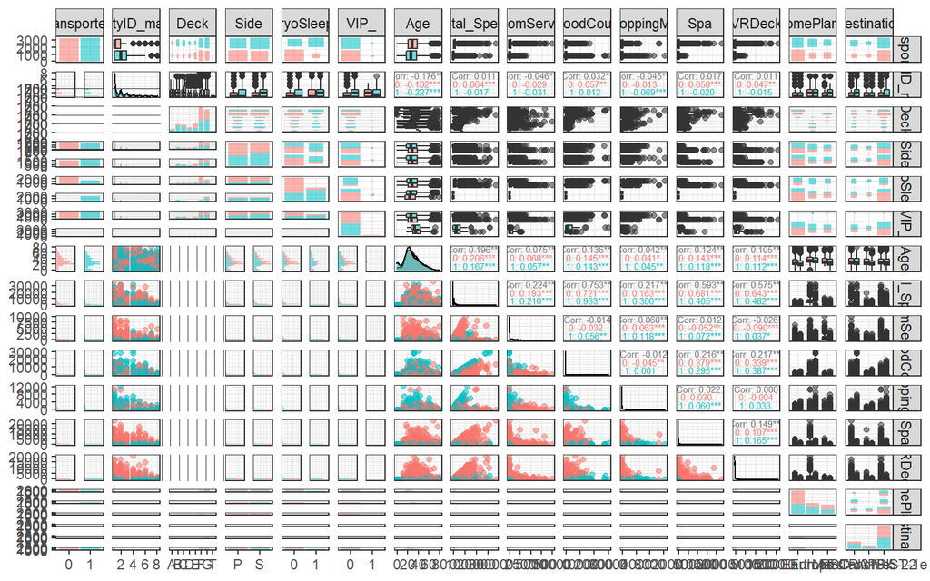

```r
#todas as variáveis
#pairs(ds1_train1_final)
ggpairs(ds1_train1_final, ggplot2::aes(colour = Transported_, alpha = 0.5),
        upper = list(continuous = wrap("cor", size=2, binwidth=0.5))
        ) + theme_bw()
```

O gráfico acima ficou muito confuso, mas pode-se notar por exemplo, que a variável dependente tem quase o mesmo número de observações tanto para Verdadeiro (1) quanto para Falso (0). Vamos então usar menos variáveis e fazer a analise gráfica melhor.

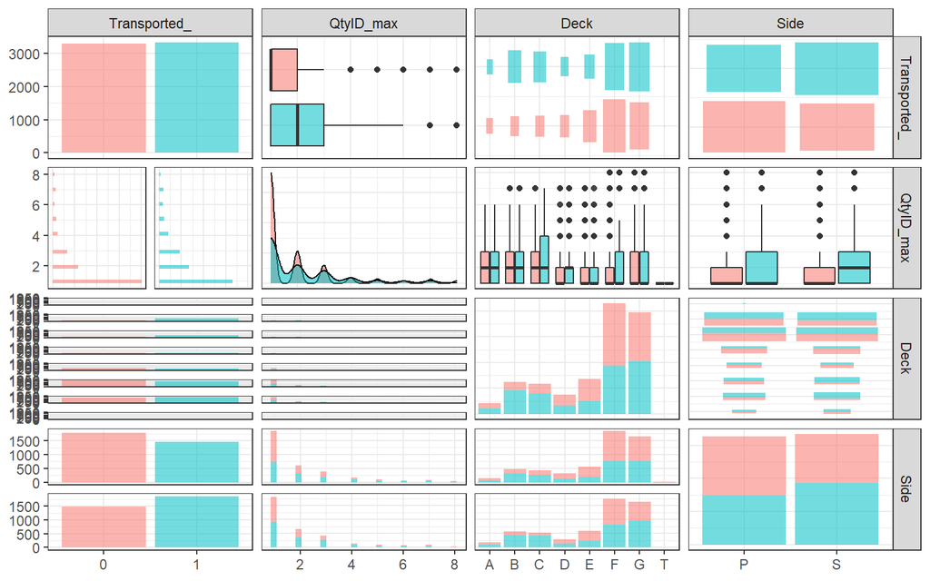

```r
#variável dependente (1) e variáveis independentes (2-4)
#pairs(ds1_train1_final)
ggpairs(ds1_train1_final[,c(1:4)], ggplot2::aes(colour = Transported_, alpha = 0.5),
        upper = list(continuous = wrap("cor", size=2, binwidth=0.5))
        ) + theme_bw()
```

O gráfico acima já nos permite ver o compartamento da variável **QtyID_max**, que nada mais é que o número máximo de pessoas por grupo. Nota-se quando a variável resposta é *verdadeira*, grupos com mais pessoas tendem a ser transpotados, enquanto que se a resposta for *falsa*, tente para grupos menores.  
Com relação a variável **Deck**, grande parte dos passageiros estavam no Deck *F* e *G* , contudo, passageiros nos Decks *B* e *C* aparentemente foram transportados com sucesso em sua maioria.  
Já olhando para a variável **Side**, tando *P* (bombordo) quando *S* (estibordo) tinham quase a mesma quantidade de passageitos, mas os que estavam a *estibordo* foram transportados com sucesso um pouco mais do que os a *bombordo*.

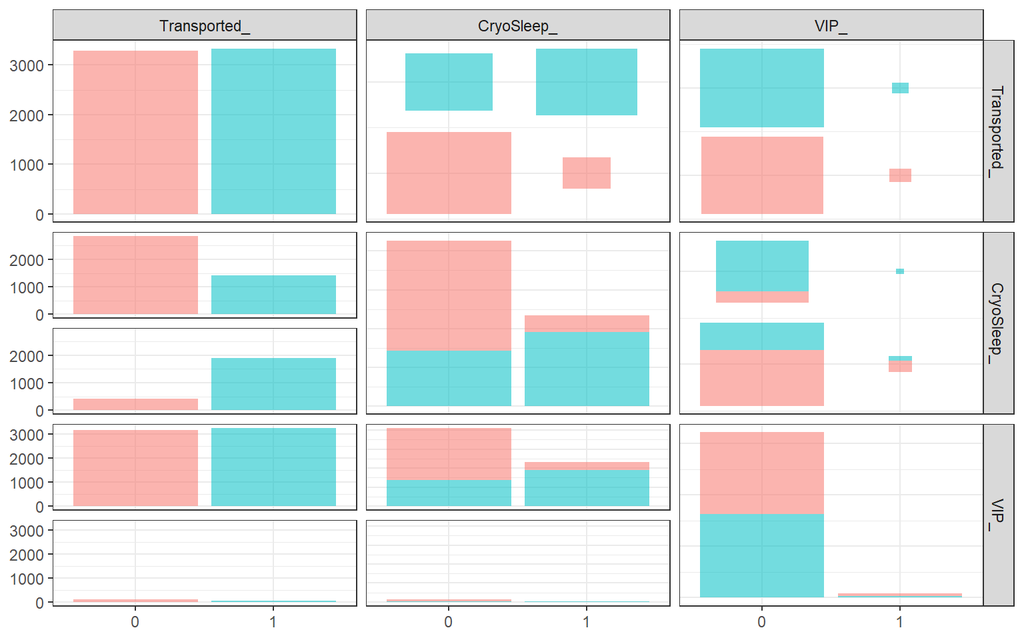

```r
#variável dependente (1) e variáveis independentes (5-6)
#pairs(ds1_train1_final)
ggpairs(ds1_train1_final[,c(1,5:6)], ggplot2::aes(colour = Transported_, alpha = 0.5),
        upper = list(continuous = wrap("cor", size=2, binwidth=0.5))
        ) + theme_bw()
```

Uma variável interessante também é **CryoSleep**, nota-se que a maior parte dos passageiros não estavam dormido durante a vigem, porém, os que estavam em CryoSleep foram transportados com sucesso.

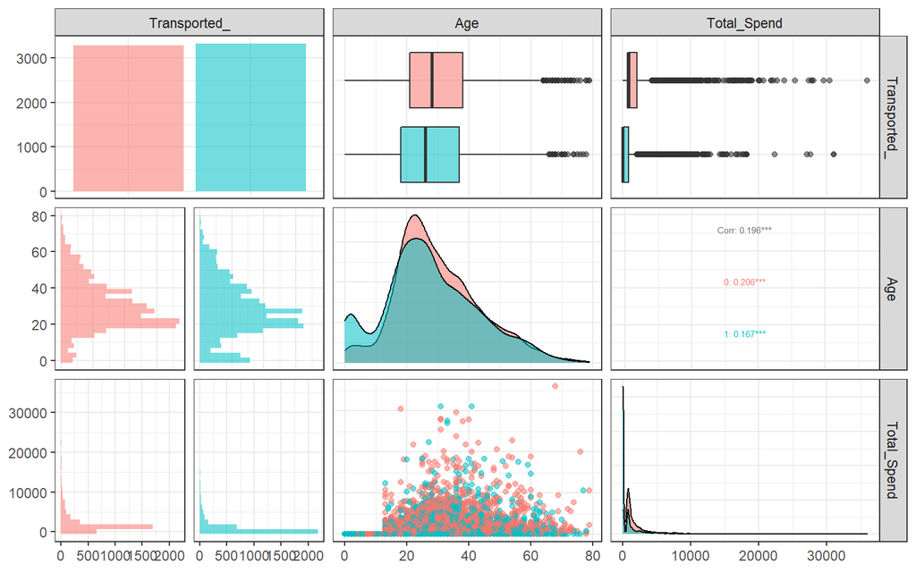

```r
#variável dependente (1) e variáveis independentes (7-8)
#pairs(ds1_train1_final)
ggpairs(ds1_train1_final[,c(1,7:8)], ggplot2::aes(colour = Transported_, alpha = 0.5),
        upper = list(continuous = wrap("cor", size=2, binwidth=0.5))
        ) + theme_bw()
```

Analisando a variável **Age**, podemos ver que a diferença é bem pouca, mas pessoas mais novas em média foram transportadas com sucesso. Contudo, a diferença aqui é bem pequena.  
Já a vairável **Total Spend** que é a variável que acumula o quanto foi gasto pelos passageiros, nos diz que também com uma leve margem, quam gastou menos teve mais chances de ser transportado com sucesso. Isso claro poderia se relacionar com a variável **CryoSleep**, afinal, se o passageiro estava dormindo durante a viagem, ele não gastou nada ou muito pouco.

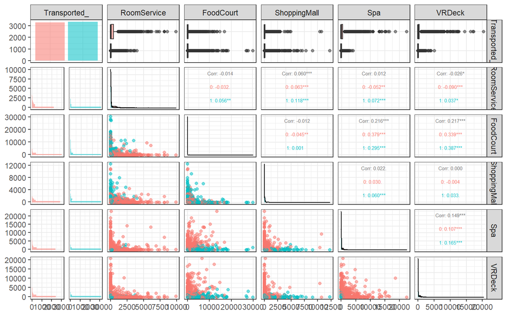

```r
#variável dependente (1) e variáveis independentes (9-13)
#pairs(ds1_train1_final)
ggpairs(ds1_train1_final[,c(1,9:13)], ggplot2::aes(colour = Transported_, alpha = 0.5),
        upper = list(continuous = wrap("cor", size=2, binwidth=0.5))
        ) + theme_bw()
```

Aqui temos as componentes da variável **Total Spend**, não vemos muita coisa aqui.

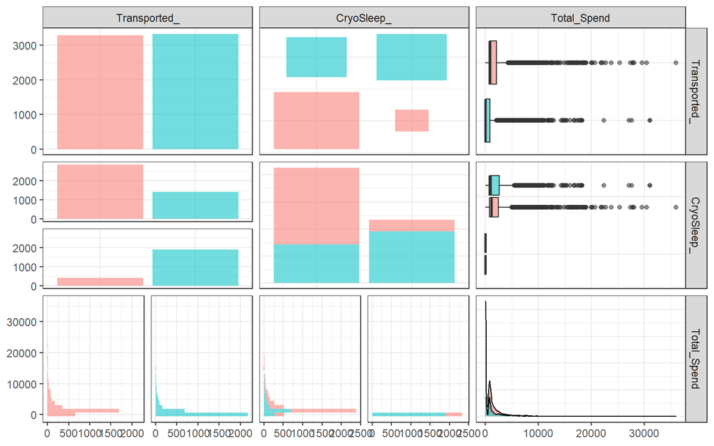

```r
#variável dependente (1) e variáveis independentes (5 & 8)
#pairs(ds1_train1_final)
ggpairs(ds1_train1_final[,c(1,5,8)], ggplot2::aes(colour = Transported_, alpha = 0.5),
        upper = list(continuous = wrap("cor", size=2, binwidth=0.5))
        ) + theme_bw()
```

Vendo o gráfico da **CryoSleep** junto com **Total Spend**, nota-se a relação citada acima, onde o passageiro que estava em CryoSleep não gastou muito.

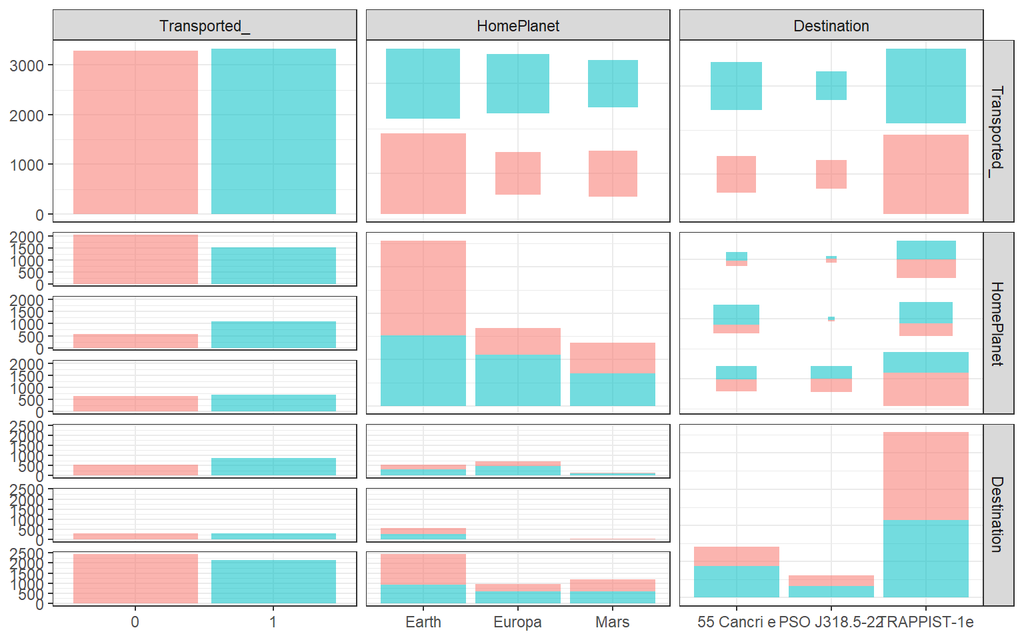

```r
#variável dependente (1) e variáveis independentes (14-15)
#pairs(ds1_train1_final)
ggpairs(ds1_train1_final[,c(1,14:15)], ggplot2::aes(colour = Transported_, alpha = 0.5),
        upper = list(continuous = wrap("cor", size=2, binwidth=0.5)),
        lower=list(combo=wrap("facethist", binwidth=0.8))
        ) + theme_bw()
```

Com relação as variáveis **HomePlanet** e **Destination**, notamos que grande parte dos passageiros vinham do planeta Terra, mas os passageiros que vinham do planeta Europa foram mais sucedidos em chegar ao destino com sucesso.  
Já se tratando no planeta destino, grande parte dos passageiros tinham como destino *TRAPPIST-1e*, mas aqueles cujo destino era o planela *55 Cancri e* tiveram mais sucesso de chegar os seu destino.

## Tipo das Variáveis

Checando se todas as variáveis estão com a classificação certa.

### Train

```r
Tipo <- sapply(ds1_train1_final, class)
cbind(Tipo) %>%  kbl %>% kable_paper(c("striped", "hover"), full_width = F, fixed_thead = T)
```

|  | Tipo |
| --- | --- |
| Transported_ | factor |
| QtyID_max | numeric |
| Deck | factor |
| Side | factor |
| CryoSleep_ | factor |
| VIP_ | factor |
| Age | numeric |
| Total_Spend | numeric |
| RoomService | numeric |
| FoodCourt | numeric |
| ShoppingMall | numeric |
| Spa | numeric |
| VRDeck | numeric |
| HomePlanet | character |
| Destination | character |

### Test

```r
Tipo_ <- sapply(ds1_test1_final, class)
cbind(Tipo_) %>%  kbl %>% kable_paper(c("striped", "hover"), full_width = F, fixed_thead = T)
```

|  | Tipo_ |
| --- | --- |
| Transported_ | factor |
| GroupID | factor |
| QtyID | factor |
| QtyID_max | numeric |
| Deck | factor |
| Num_cab | factor |
| Side | factor |
| CryoSleep_ | factor |
| VIP_ | factor |
| Age | numeric |
| Total_Spend | numeric |
| RoomService | numeric |
| FoodCourt | numeric |
| ShoppingMall | numeric |
| Spa | numeric |
| VRDeck | numeric |
| HomePlanet | character |
| Destination | character |

# Modelagem [Modeling]

A variável resposta é do tipo Binária (Sim/Não, Verdadeiro/Falso) para o caso em que o passageiro foi ou não transportado para uma dimensão alternativa.  
Desta forma, vamos utilizar o modelo que prediz uma categoria, sendo assim modelos de classificação.  
E dentre os modelos estudados, vamos usar a **Regressão Logística Binária**.  
Como foi visto acima, utilizamos a base **Sample_Submission** para obter os valores da variável resposta da base **Test** que não estava presente no arquivo. Contudo, posso separar a base **Train** para fazer a validação do modelo e depois prever os valores para a base **Test**, ou considerar que os valores se **Sample_Submission** são os valores corretos e que, nesse caso, todos os passageiros listados na base **Test** não foram transportados para o planeta destino (isso porquê a variável *Transported* tem valor FALSE para todas as observações).  
Por escolha, vou fazer a avaliação do modelo de maneira separada, criar uma segunda base **Test** a partir da base **Train** e depois aplicar os o modelo na base **Test** inicial. Assim, vamos separar a base **Train** em *Train_train* e *Train_test*.

```r
# Using base R
set.seed(123)  # for reproducibility
index_1 <- sample(1:nrow(ds1_train1_final), round(nrow(ds1_train1_final) * 0.7))
ds1_train1_final_train <- ds1_train1_final[index_1, ]
ds1_train1_final_test  <- ds1_train1_final[-index_1, ]
```

## Modelo 1

Modelo com todas as variáveis.

```r
##Model 1
travel_model1 <- glm(Transported_ ~ . ,
                     data = ds1_train1_final[,-c(9:13)], family = binomial)
summary(travel_model1)
```

```
##
## Call:
## glm(formula = Transported_ ~ ., family = binomial, data = ds1_train1_final[,
##     -c(9:13)])
##
## Deviance Residuals:
##     Min       1Q   Median       3Q      Max
## -2.4754  -0.8667   0.2266   0.8165   3.0286
##
## Coefficients:
##                            Estimate Std. Error z value             Pr(>|z|)
## (Intercept)              -0.7118639  0.2740235  -2.598             0.009382 **
## QtyID_max                 0.0116613  0.0189754   0.615             0.538851
## DeckB                     0.8355423  0.1992642   4.193       0.000027512308 ***
## DeckC                     0.9578285  0.1988488   4.817       0.000001458284 ***
## DeckD                     0.2561443  0.2339825   1.095             0.273641
## DeckE                     0.0858849  0.2468095   0.348             0.727855
## DeckF                     0.6056762  0.2536196   2.388             0.016934 *
## DeckG                     0.2413365  0.2667100   0.905             0.365537
## DeckT                     1.2556513  1.4474865   0.867             0.385684
## SideS                     0.5174536  0.0582259   8.887 < 0.0000000000000002 ***
## CryoSleep_1               1.9197863  0.0815639  23.537 < 0.0000000000000002 ***
## VIP_1                    -0.3244138  0.1950275  -1.663             0.096227 .
## Age                      -0.0135849  0.0021698  -6.261       0.000000000383 ***
## Total_Spend              -0.0001550  0.0000162  -9.569 < 0.0000000000000002 ***
## HomePlanetEuropa          1.2693447  0.2014722   6.300       0.000000000297 ***
## HomePlanetMars            0.3944312  0.0943608   4.180       0.000029146935 ***
## DestinationPSO J318.5-22 -0.4121807  0.1173693  -3.512             0.000445 ***
## DestinationTRAPPIST-1e   -0.4619655  0.0765097  -6.038       0.000000001560 ***
## ---
## Signif. codes:  0 '***' 0.001 '**' 0.01 '*' 0.05 '.' 0.1 ' ' 1
##
## (Dispersion parameter for binomial family taken to be 1)
##
##     Null deviance: 9157.5  on 6605  degrees of freedom
## Residual deviance: 7128.4  on 6588  degrees of freedom
## AIC: 7164.4
##
## Number of Fisher Scoring iterations: 5
```

```r
exp(travel_model1$coefficients)
```

```
##              (Intercept)                QtyID_max                    DeckB
##                0.4907287                1.0117296                2.3060642
##                    DeckC                    DeckD                    DeckE
##                2.6060313                1.2919392                1.0896809
##                    DeckF                    DeckG                    DeckT
##                1.8324910                1.2729494                3.5101238
##                    SideS              CryoSleep_1                    VIP_1
##                1.6777500                6.8195009                0.7229510
##                      Age              Total_Spend         HomePlanetEuropa
##                0.9865070                0.9998450                3.5585198
##           HomePlanetMars DestinationPSO J318.5-22   DestinationTRAPPIST-1e
##                1.4835401                0.6622046                0.6300441
```

Transformando a exponencial dos coeficientes:

```r
##Model 1 - exponential coeff
exp(travel_model1$coefficients)
```

```
##              (Intercept)                QtyID_max                    DeckB
##                0.4907287                1.0117296                2.3060642
##                    DeckC                    DeckD                    DeckE
##                2.6060313                1.2919392                1.0896809
##                    DeckF                    DeckG                    DeckT
##                1.8324910                1.2729494                3.5101238
##                    SideS              CryoSleep_1                    VIP_1
##                1.6777500                6.8195009                0.7229510
##                      Age              Total_Spend         HomePlanetEuropa
##                0.9865070                0.9998450                3.5585198
##           HomePlanetMars DestinationPSO J318.5-22   DestinationTRAPPIST-1e
##                1.4835401                0.6622046                0.6300441
```

## Modelo 2

Modelo com a variável **CryoSleep** somente.

```r
##Model 2
travel_model2 <- glm(Transported_ ~ CryoSleep_ ,
                     data = ds1_train1_final, family = binomial)
summary(travel_model2)
```

```
##
## Call:
## glm(formula = Transported_ ~ CryoSleep_, family = binomial, data = ds1_train1_final)
##
## Deviance Residuals:
##     Min       1Q   Median       3Q      Max
## -1.8427  -0.8995   0.6360   0.6360   1.4836
##
## Coefficients:
##             Estimate Std. Error z value            Pr(>|z|)
## (Intercept) -0.69596    0.03246  -21.44 <0.0000000000000002 ***
## CryoSleep_1  2.19141    0.06262   35.00 <0.0000000000000002 ***
## ---
## Signif. codes:  0 '***' 0.001 '**' 0.01 '*' 0.05 '.' 0.1 ' ' 1
##
## (Dispersion parameter for binomial family taken to be 1)
##
##     Null deviance: 9157.5  on 6605  degrees of freedom
## Residual deviance: 7657.6  on 6604  degrees of freedom
## AIC: 7661.6
##
## Number of Fisher Scoring iterations: 4
```

Transformando a exponencial dos coeficientes:

```r
##Model 2 - exponential coeff
exp(travel_model2$coefficients)
```

```
## (Intercept) CryoSleep_1
##   0.4985975   8.9478157
```

## Modelo 3

Modelo com a variável **CryoSleep** e **HomePlanet**.

```r
##Model 3
travel_model3 <- glm(Transported_ ~  CryoSleep_ + HomePlanet ,
                     data = ds1_train1_final, family = binomial)
summary(travel_model3)
```

```
##
## Call:
## glm(formula = Transported_ ~ CryoSleep_ + HomePlanet, family = binomial,
##     data = ds1_train1_final)
##
## Deviance Residuals:
##     Min       1Q   Median       3Q      Max
## -2.1069  -0.8015   0.4796   0.7255   1.6075
##
## Coefficients:
##                  Estimate Std. Error z value             Pr(>|z|)
## (Intercept)      -0.97082    0.04213  -23.04 < 0.0000000000000002 ***
## CryoSleep_1       2.17137    0.06342   34.24 < 0.0000000000000002 ***
## HomePlanetEuropa  0.90404    0.06872   13.15 < 0.0000000000000002 ***
## HomePlanetMars    0.27838    0.07212    3.86             0.000113 ***
## ---
## Signif. codes:  0 '***' 0.001 '**' 0.01 '*' 0.05 '.' 0.1 ' ' 1
##
## (Dispersion parameter for binomial family taken to be 1)
##
##     Null deviance: 9157.5  on 6605  degrees of freedom
## Residual deviance: 7480.7  on 6602  degrees of freedom
## AIC: 7488.7
##
## Number of Fisher Scoring iterations: 4
```

Transformando a exponencial dos coeficientes:

```r
exp(travel_model3$coefficients)
```

```
##      (Intercept)      CryoSleep_1 HomePlanetEuropa   HomePlanetMars
##        0.3787738        8.7702508        2.4695637        1.3209931
```

## Modelo 4

Modelo com a variável **CryoSleep**, **HomePlant** e **Destination**.

```r
##Model 4
travel_model4 <- glm(Transported_ ~ CryoSleep_ + HomePlanet + Destination ,
                     data = ds1_train1_final, family = binomial)
summary(travel_model4)
```

```
##
## Call:
## glm(formula = Transported_ ~ CryoSleep_ + HomePlanet + Destination,
##     family = binomial, data = ds1_train1_final)
##
## Deviance Residuals:
##     Min       1Q   Median       3Q      Max
## -2.2138  -0.8841   0.4247   0.7431   1.6545
##
## Coefficients:
##                          Estimate Std. Error z value             Pr(>|z|)
## (Intercept)              -0.62025    0.07354  -8.435 < 0.0000000000000002 ***
## CryoSleep_1               2.17638    0.06429  33.852 < 0.0000000000000002 ***
## HomePlanetEuropa          0.80423    0.07183  11.196 < 0.0000000000000002 ***
## HomePlanetMars            0.29285    0.07360   3.979         0.0000691558 ***
## DestinationPSO J318.5-22 -0.45488    0.11682  -3.894         0.0000986673 ***
## DestinationTRAPPIST-1e   -0.41042    0.07312  -5.613         0.0000000199 ***
## ---
## Signif. codes:  0 '***' 0.001 '**' 0.01 '*' 0.05 '.' 0.1 ' ' 1
##
## (Dispersion parameter for binomial family taken to be 1)
##
##     Null deviance: 9157.5  on 6605  degrees of freedom
## Residual deviance: 7447.7  on 6600  degrees of freedom
## AIC: 7459.7
##
## Number of Fisher Scoring iterations: 4
```

Transformando a exponencial dos coeficientes:

```r
exp(travel_model4$coefficients)
```

```
##              (Intercept)              CryoSleep_1         HomePlanetEuropa
##                0.5378125                8.8143447                2.2349651
##           HomePlanetMars DestinationPSO J318.5-22   DestinationTRAPPIST-1e
##                1.3402456                0.6345243                0.6633734
```

## Modelo 5

Modelo com a variável **CryoSleep** e **Destination**.

```r
##Model 5
travel_model5 <- glm(Transported_ ~ CryoSleep_ + Destination ,
                     data = ds1_train1_final, family = binomial)
summary(travel_model5)
```

```
##
## Call:
## glm(formula = Transported_ ~ CryoSleep_ + Destination, family = binomial,
##     data = ds1_train1_final)
##
## Deviance Residuals:
##     Min       1Q   Median       3Q      Max
## -2.0542  -0.8629   0.5084   0.6605   1.6432
##
## Coefficients:
##                          Estimate Std. Error z value             Pr(>|z|)
## (Intercept)              -0.22702    0.06306  -3.600             0.000318 ***
## CryoSleep_1               2.20762    0.06368  34.668 < 0.0000000000000002 ***
## DestinationPSO J318.5-22 -0.82306    0.11218  -7.337 0.000000000000218434 ***
## DestinationTRAPPIST-1e   -0.56916    0.06981  -8.153 0.000000000000000356 ***
## ---
## Signif. codes:  0 '***' 0.001 '**' 0.01 '*' 0.05 '.' 0.1 ' ' 1
##
## (Dispersion parameter for binomial family taken to be 1)
##
##     Null deviance: 9157.5  on 6605  degrees of freedom
## Residual deviance: 7575.0  on 6602  degrees of freedom
## AIC: 7583
##
## Number of Fisher Scoring iterations: 4
```

Transformando a exponencial dos coeficientes:

```r
exp(travel_model5$coefficients)
```

```
##              (Intercept)              CryoSleep_1 DestinationPSO J318.5-22
##                0.7969017                9.0940422                0.4390862
##   DestinationTRAPPIST-1e
##                0.5659990
```

## Modelo 6

Modelo com a variável **CryoSleep** , **HomePlanet**, **Destination** e **QtyID_max**.

```r
##Model 6
travel_model6 <- glm(Transported_ ~ CryoSleep_ + HomePlanet + Destination + QtyID_max  ,
                     data = ds1_train1_final, family = binomial)
summary(travel_model6)
```

```
##
## Call:
## glm(formula = Transported_ ~ CryoSleep_ + HomePlanet + Destination +
##     QtyID_max, family = binomial, data = ds1_train1_final)
##
## Deviance Residuals:
##     Min       1Q   Median       3Q      Max
## -2.1842  -0.8693   0.3944   0.7586   1.6675
##
## Coefficients:
##                          Estimate Std. Error z value             Pr(>|z|)
## (Intercept)              -0.70629    0.08127  -8.690 < 0.0000000000000002 ***
## CryoSleep_1               2.16702    0.06437  33.665 < 0.0000000000000002 ***
## HomePlanetEuropa          0.78293    0.07233  10.825 < 0.0000000000000002 ***
## HomePlanetMars            0.29014    0.07362   3.941         0.0000811485 ***
## DestinationPSO J318.5-22 -0.44271    0.11695  -3.785             0.000153 ***
## DestinationTRAPPIST-1e   -0.40742    0.07316  -5.569         0.0000000257 ***
## QtyID_max                 0.04515    0.01800   2.508             0.012131 *
## ---
## Signif. codes:  0 '***' 0.001 '**' 0.01 '*' 0.05 '.' 0.1 ' ' 1
##
## (Dispersion parameter for binomial family taken to be 1)
##
##     Null deviance: 9157.5  on 6605  degrees of freedom
## Residual deviance: 7441.4  on 6599  degrees of freedom
## AIC: 7455.4
##
## Number of Fisher Scoring iterations: 4
```

Transformando a exponencial dos coeficientes:

```r
exp(travel_model6$coefficients)
```

```
##              (Intercept)              CryoSleep_1         HomePlanetEuropa
##                0.4934693                8.7322471                2.1878770
##           HomePlanetMars DestinationPSO J318.5-22   DestinationTRAPPIST-1e
##                1.3366092                0.6422912                0.6653677
##                QtyID_max
##                1.0461863
```

## Modelo 7

Modelo com a variável **CryoSleep** , **HomePlanet**, **Destination**, **QtyID_max** e **Age**.

```r
##Model 7
travel_model7 <- glm(Transported_ ~ CryoSleep_ + HomePlanet + Destination + QtyID_max + Age ,
                     data = ds1_train1_final, family = binomial)
summary(travel_model7)
```

```
##
## Call:
## glm(formula = Transported_ ~ CryoSleep_ + HomePlanet + Destination +
##     QtyID_max + Age, family = binomial, data = ds1_train1_final)
##
## Deviance Residuals:
##     Min       1Q   Median       3Q      Max
## -2.2654  -0.8626   0.3756   0.7600   1.9528
##
## Coefficients:
##                           Estimate Std. Error z value             Pr(>|z|)
## (Intercept)              -0.284948   0.100808  -2.827             0.004704 **
## CryoSleep_1               2.139967   0.064604  33.124 < 0.0000000000000002 ***
## HomePlanetEuropa          0.941246   0.076323  12.332 < 0.0000000000000002 ***
## HomePlanetMars            0.346612   0.074302   4.665     0.00000308716125 ***
## DestinationPSO J318.5-22 -0.401641   0.117730  -3.412             0.000646 ***
## DestinationTRAPPIST-1e   -0.389318   0.073388  -5.305     0.00000011273108 ***
## QtyID_max                 0.018093   0.018510   0.977             0.328357
## Age                      -0.014727   0.002106  -6.995     0.00000000000266 ***
## ---
## Signif. codes:  0 '***' 0.001 '**' 0.01 '*' 0.05 '.' 0.1 ' ' 1
##
## (Dispersion parameter for binomial family taken to be 1)
##
##     Null deviance: 9157.5  on 6605  degrees of freedom
## Residual deviance: 7391.8  on 6598  degrees of freedom
## AIC: 7407.8
##
## Number of Fisher Scoring iterations: 4
```

Transformando a exponencial dos coeficientes:

```r
exp(travel_model7$coefficients)
```

```
##              (Intercept)              CryoSleep_1         HomePlanetEuropa
##                0.7520536                8.4991582                2.5631732
##           HomePlanetMars DestinationPSO J318.5-22   DestinationTRAPPIST-1e
##                1.4142678                0.6692209                0.6775191
##                QtyID_max                      Age
##                1.0182573                0.9853806
```

## Modelo 8

Modelo com a variável **CryoSleep** , **HomePlanet**, **Destination** e **Age**.

```r
##Model 8
travel_model8 <- glm(Transported_ ~ CryoSleep_ + HomePlanet + Destination + Age ,
                     data = ds1_train1_final, family = binomial)
summary(travel_model8)
```

```
##
## Call:
## glm(formula = Transported_ ~ CryoSleep_ + HomePlanet + Destination +
##     Age, family = binomial, data = ds1_train1_final)
##
## Deviance Residuals:
##     Min       1Q   Median       3Q      Max
## -2.2622  -0.8628   0.3786   0.7569   1.9552
##
## Coefficients:
##                          Estimate Std. Error z value             Pr(>|z|)
## (Intercept)              -0.23978    0.08956  -2.677             0.007420 **
## CryoSleep_1               2.14268    0.06456  33.191 < 0.0000000000000002 ***
## HomePlanetEuropa          0.95423    0.07519  12.691 < 0.0000000000000002 ***
## HomePlanetMars            0.34934    0.07425   4.705    0.000002539136721 ***
## DestinationPSO J318.5-22 -0.40518    0.11768  -3.443             0.000575 ***
## DestinationTRAPPIST-1e   -0.38996    0.07337  -5.315    0.000000106868372 ***
## Age                      -0.01516    0.00206  -7.358    0.000000000000187 ***
## ---
## Signif. codes:  0 '***' 0.001 '**' 0.01 '*' 0.05 '.' 0.1 ' ' 1
##
## (Dispersion parameter for binomial family taken to be 1)
##
##     Null deviance: 9157.5  on 6605  degrees of freedom
## Residual deviance: 7392.7  on 6599  degrees of freedom
## AIC: 7406.7
##
## Number of Fisher Scoring iterations: 4
```

Transformando a exponencial dos coeficientes:

```r
exp(travel_model8$coefficients)
```

```
##              (Intercept)              CryoSleep_1         HomePlanetEuropa
##                0.7868022                8.5222783                2.5966814
##           HomePlanetMars DestinationPSO J318.5-22   DestinationTRAPPIST-1e
##                1.4181337                0.6668541                0.6770825
##                      Age
##                0.9849570
```

## Modelo 9

Modelo com a variável **CryoSleep** , **HomePlanet**, **Destination**, **Age** e **Deck**.

```r
##Model 9
travel_model9 <- glm(Transported_ ~ CryoSleep_ + HomePlanet + Destination + Age + Deck ,
                     data = ds1_train1_final, family = binomial)
summary(travel_model9)
```

```
##
## Call:
## glm(formula = Transported_ ~ CryoSleep_ + HomePlanet + Destination +
##     Age + Deck, family = binomial, data = ds1_train1_final)
##
## Deviance Residuals:
##     Min       1Q   Median       3Q      Max
## -2.3605  -0.8855   0.3347   0.7800   2.0526
##
## Coefficients:
##                           Estimate Std. Error z value             Pr(>|z|)
## (Intercept)              -0.604323   0.255610  -2.364             0.018067 *
## CryoSleep_1               2.243497   0.073102  30.690 < 0.0000000000000002 ***
## HomePlanetEuropa          0.834331   0.189292   4.408   0.0000104506933800 ***
## HomePlanetMars            0.249740   0.092108   2.711             0.006700 **
## DestinationPSO J318.5-22 -0.382968   0.116926  -3.275             0.001055 **
## DestinationTRAPPIST-1e   -0.374132   0.073985  -5.057   0.0000004262328965 ***
## Age                      -0.015864   0.002094  -7.578   0.0000000000000352 ***
## DeckB                     0.634304   0.184882   3.431             0.000602 ***
## DeckC                     0.654599   0.183188   3.573             0.000352 ***
## DeckD                     0.205524   0.221468   0.928             0.353403
## DeckE                     0.123433   0.234039   0.527             0.597914
## DeckF                     0.613528   0.241154   2.544             0.010955 *
## DeckG                     0.175651   0.254659   0.690             0.490351
## DeckT                     0.778694   1.423246   0.547             0.584292
## ---
## Signif. codes:  0 '***' 0.001 '**' 0.01 '*' 0.05 '.' 0.1 ' ' 1
##
## (Dispersion parameter for binomial family taken to be 1)
##
##     Null deviance: 9157.5  on 6605  degrees of freedom
## Residual deviance: 7330.9  on 6592  degrees of freedom
## AIC: 7358.9
##
## Number of Fisher Scoring iterations: 4
```

Transformando a exponencial dos coeficientes:

```r
exp(travel_model9$coefficients)
```

```
##              (Intercept)              CryoSleep_1         HomePlanetEuropa
##                0.5464445                9.4262365                2.3032715
##           HomePlanetMars DestinationPSO J318.5-22   DestinationTRAPPIST-1e
##                1.2836921                0.6818349                0.6878862
##                      Age                    DeckB                    DeckC
##                0.9842609                1.8857099                1.9243712
##                    DeckD                    DeckE                    DeckF
##                1.2281686                1.1313737                1.8469363
##                    DeckG                    DeckT
##                1.1920222                2.1786259
```

## Modelo 10

Modelo com a variável **CryoSleep** , **HomePlanet**, **Destination**, **Age**, **Deck**, **Side** e **Total_Spend**.

```r
##Model 10
travel_model10 <- glm(Transported_ ~ CryoSleep_ + HomePlanet + Destination + Age + Deck + Side + Total_Spend ,
                     data = ds1_train1_final, family = binomial)
summary(travel_model10)
```

```
##
## Call:
## glm(formula = Transported_ ~ CryoSleep_ + HomePlanet + Destination +
##     Age + Deck + Side + Total_Spend, family = binomial, data = ds1_train1_final)
##
## Deviance Residuals:
##     Min       1Q   Median       3Q      Max
## -2.4611  -0.8702   0.2280   0.8220   2.9560
##
## Coefficients:
##                             Estimate  Std. Error z value             Pr(>|z|)
## (Intercept)              -0.72446504  0.26819863  -2.701             0.006908
## CryoSleep_1               1.92678152  0.08139178  23.673 < 0.0000000000000002
## HomePlanetEuropa          1.27491764  0.20107331   6.341      0.0000000002289
## HomePlanetMars            0.38681701  0.09362686   4.131      0.0000360443334
## DestinationPSO J318.5-22 -0.42287168  0.11715210  -3.610             0.000307
## DestinationTRAPPIST-1e   -0.46068849  0.07647717  -6.024      0.0000000017030
## Age                      -0.01400358  0.00212587  -6.587      0.0000000000448
## DeckB                     0.85993056  0.19824101   4.338      0.0000143913741
## DeckC                     0.99037953  0.19751903   5.014      0.0000005328320
## DeckD                     0.28794424  0.23271852   1.237             0.215973
## DeckE                     0.12506813  0.24506314   0.510             0.609806
## DeckF                     0.64959229  0.25170709   2.581             0.009859
## DeckG                     0.28577709  0.26514909   1.078             0.281124
## DeckT                     1.29588919  1.44737904   0.895             0.370608
## SideS                     0.51923110  0.05820663   8.920 < 0.0000000000000002
## Total_Spend              -0.00015612  0.00001619  -9.645 < 0.0000000000000002
##
## (Intercept)              **
## CryoSleep_1              ***
## HomePlanetEuropa         ***
## HomePlanetMars           ***
## DestinationPSO J318.5-22 ***
## DestinationTRAPPIST-1e   ***
## Age                      ***
## DeckB                    ***
## DeckC                    ***
## DeckD
## DeckE
## DeckF                    **
## DeckG
## DeckT
## SideS                    ***
## Total_Spend              ***
## ---
## Signif. codes:  0 '***' 0.001 '**' 0.01 '*' 0.05 '.' 0.1 ' ' 1
##
## (Dispersion parameter for binomial family taken to be 1)
##
##     Null deviance: 9157.5  on 6605  degrees of freedom
## Residual deviance: 7131.6  on 6590  degrees of freedom
## AIC: 7163.6
##
## Number of Fisher Scoring iterations: 5
```

Transformando a exponencial dos coeficientes:

```r
exp(travel_model10$coefficients)
```

```
##              (Intercept)              CryoSleep_1         HomePlanetEuropa
##                0.4845837                6.8673721                3.5784067
##           HomePlanetMars DestinationPSO J318.5-22   DestinationTRAPPIST-1e
##                1.4722871                0.6551627                0.6308492
##                      Age                    DeckB                    DeckC
##                0.9860940                2.3629966                2.6922561
##                    DeckD                    DeckE                    DeckF
##                1.3336829                1.1332257                1.9147600
##                    DeckG                    DeckT                    SideS
##                1.3307958                3.6542438                1.6807348
##              Total_Spend
##                0.9998439
```

## Modelo 11

Modelo com a variável **CryoSleep** , **HomePlanet**, **Destination**, **Age**, **Deck** e **Total_Spend**.

```r
##Model 11
travel_model11 <- glm(Transported_ ~ CryoSleep_ + HomePlanet + Destination + Age + Deck + Total_Spend ,
                     data = ds1_train1_final, family = binomial)
summary(travel_model11)
```

```
##
## Call:
## glm(formula = Transported_ ~ CryoSleep_ + HomePlanet + Destination +
##     Age + Deck + Total_Spend, family = binomial, data = ds1_train1_final)
##
## Deviance Residuals:
##     Min       1Q   Median       3Q      Max
## -2.5571  -0.8807   0.2580   0.8052   3.0099
##
## Coefficients:
##                             Estimate  Std. Error z value             Pr(>|z|)
## (Intercept)              -0.46764950  0.26484913  -1.766             0.077443
## CryoSleep_1               1.90740914  0.08069302  23.638 < 0.0000000000000002
## HomePlanetEuropa          1.28540558  0.20004731   6.426      0.0000000001314
## HomePlanetMars            0.36895379  0.09290415   3.971      0.0000714701071
## DestinationPSO J318.5-22 -0.41740740  0.11664915  -3.578             0.000346
## DestinationTRAPPIST-1e   -0.44817481  0.07593122  -5.902      0.0000000035830
## Age                      -0.01386242  0.00210806  -6.576      0.0000000000484
## DeckB                     0.84093304  0.19676605   4.274      0.0000192194350
## DeckC                     0.98132779  0.19629946   4.999      0.0000005758761
## DeckD                     0.26890392  0.23125199   1.163             0.244903
## DeckE                     0.13983355  0.24380008   0.574             0.566267
## DeckF                     0.64503532  0.25025323   2.578             0.009951
## DeckG                     0.28434582  0.26346119   1.079             0.280467
## DeckT                     0.99623336  1.44604621   0.689             0.490864
## Total_Spend              -0.00015344  0.00001606  -9.557 < 0.0000000000000002
##
## (Intercept)              .
## CryoSleep_1              ***
## HomePlanetEuropa         ***
## HomePlanetMars           ***
## DestinationPSO J318.5-22 ***
## DestinationTRAPPIST-1e   ***
## Age                      ***
## DeckB                    ***
## DeckC                    ***
## DeckD
## DeckE
## DeckF                    **
## DeckG
## DeckT
## Total_Spend              ***
## ---
## Signif. codes:  0 '***' 0.001 '**' 0.01 '*' 0.05 '.' 0.1 ' ' 1
##
## (Dispersion parameter for binomial family taken to be 1)
##
##     Null deviance: 9157.5  on 6605  degrees of freedom
## Residual deviance: 7212.2  on 6591  degrees of freedom
## AIC: 7242.2
##
## Number of Fisher Scoring iterations: 4
```

Transformando a exponencial dos coeficientes:

```r
exp(travel_model11$coefficients)
```

```
##              (Intercept)              CryoSleep_1         HomePlanetEuropa
##                0.6264731                6.7356151                3.6161343
##           HomePlanetMars DestinationPSO J318.5-22   DestinationTRAPPIST-1e
##                1.4462208                0.6587525                0.6387930
##                      Age                    DeckB                    DeckC
##                0.9862332                2.3185292                2.6679964
##                    DeckD                    DeckE                    DeckF
##                1.3085294                1.1500823                1.9060544
##                    DeckG                    DeckT              Total_Spend
##                1.3288924                2.7080623                0.9998466
```

## Modelo 12

Modelo com a variável **CryoSleep** , **HomePlanet**, **Destination**, **Age** e **Total_Spend**.

```r
##Model 12
travel_model12 <- glm(Transported_ ~ CryoSleep_ + HomePlanet + Destination + Age + Total_Spend ,
                     data = ds1_train1_final, family = binomial)
summary(travel_model12)
```

```
##
## Call:
## glm(formula = Transported_ ~ CryoSleep_ + HomePlanet + Destination +
##     Age + Total_Spend, family = binomial, data = ds1_train1_final)
##
## Deviance Residuals:
##     Min       1Q   Median       3Q      Max
## -2.4453  -0.8486   0.3048   0.7866   2.6653
##
## Coefficients:
##                             Estimate  Std. Error z value             Pr(>|z|)
## (Intercept)              -0.04987713  0.09231933  -0.540             0.589013
## CryoSleep_1               1.84766499  0.07144832  25.860 < 0.0000000000000002
## HomePlanetEuropa          1.47639171  0.09475005  15.582 < 0.0000000000000002
## HomePlanetMars            0.42883857  0.07433360   5.769      0.0000000079692
## DestinationPSO J318.5-22 -0.43064880  0.11710862  -3.677             0.000236
## DestinationTRAPPIST-1e   -0.46079605  0.07521326  -6.127      0.0000000008982
## Age                      -0.01343633  0.00207256  -6.483      0.0000000000899
## Total_Spend              -0.00014154  0.00001537  -9.211 < 0.0000000000000002
##
## (Intercept)
## CryoSleep_1              ***
## HomePlanetEuropa         ***
## HomePlanetMars           ***
## DestinationPSO J318.5-22 ***
## DestinationTRAPPIST-1e   ***
## Age                      ***
## Total_Spend              ***
## ---
## Signif. codes:  0 '***' 0.001 '**' 0.01 '*' 0.05 '.' 0.1 ' ' 1
##
## (Dispersion parameter for binomial family taken to be 1)
##
##     Null deviance: 9157.5  on 6605  degrees of freedom
## Residual deviance: 7284.6  on 6598  degrees of freedom
## AIC: 7300.6
##
## Number of Fisher Scoring iterations: 4
```

Transformando a exponencial dos coeficientes:

```r
exp(travel_model12$coefficients)
```

```
##              (Intercept)              CryoSleep_1         HomePlanetEuropa
##                0.9513463                6.3449866                4.3771232
##           HomePlanetMars DestinationPSO J318.5-22   DestinationTRAPPIST-1e
##                1.5354731                0.6500872                0.6307813
##                      Age              Total_Spend
##                0.9866535                0.9998585
```

## AIC

```r
ft1 <- as.data.frame(cbind(c(travel_model1$aic,
        travel_model2$aic,
        travel_model3$aic,
        travel_model4$aic,
        travel_model5$aic,
        travel_model6$aic,
        travel_model7$aic,
        travel_model8$aic,
        travel_model9$aic,
        travel_model10$aic,
        travel_model11$aic,
        travel_model12$aic
        )
        ))
colnames(ft1) <- c("AIC")
ft1$Formula <- c(travel_model1$formula,
                 travel_model2$formula,
                 travel_model3$formula,
                 travel_model4$formula,
                 travel_model5$formula,
                 travel_model6$formula,
                 travel_model7$formula,
                 travel_model8$formula,
                 travel_model9$formula,
                 travel_model10$formula,
                 travel_model11$formula,
                 travel_model12$formula
                    )
row.names(ft1) <- c("Modelo 1:",
                    "Modelo 2:",
                    "Modelo 3:",
                    "Modelo 4:",
                    "Modelo 5:",
                    "Modelo 6:",
                    "Modelo 7:",
                    "Modelo 8:",
                    "Modelo 9:",
                    "Modelo 10:",
                    "Modelo 11:",
                    "Modelo 12:"
                    )

ft1 %>%  kbl %>% kable_paper(c("striped", "hover"), full_width = F, fixed_thead = T)
```

|  | AIC | Formula |
| --- | --- | --- |
| Modelo 1: | 7164.395 | Transported_ ~ . |
| Modelo 2: | 7661.603 | Transported_ ~ CryoSleep_ |
| Modelo 3: | 7488.712 | Transported_ ~ CryoSleep_ + HomePlanet |
| Modelo 4: | 7459.699 | Transported_ ~ CryoSleep_ + HomePlanet + Destination |
| Modelo 5: | 7583.008 | Transported_ ~ CryoSleep_ + Destination |
| Modelo 6: | 7455.417 | Transported_ ~ CryoSleep_ + HomePlanet + Destination + QtyID_max |
| Modelo 7: | 7407.766 | Transported_ ~ CryoSleep_ + HomePlanet + Destination + QtyID_max + , Age |
| Modelo 8: | 7406.720 | Transported_ ~ CryoSleep_ + HomePlanet + Destination + Age |
| Modelo 9: | 7358.925 | Transported_ ~ CryoSleep_ + HomePlanet + Destination + Age + , Deck |
| Modelo 10: | 7163.629 | Transported_ ~ CryoSleep_ + HomePlanet + Destination + Age + , Deck + Side + Total_Spend |
| Modelo 11: | 7242.192 | Transported_ ~ CryoSleep_ + HomePlanet + Destination + Age + , Deck + Total_Spend |
| Modelo 12: | 7300.579 | Transported_ ~ CryoSleep_ + HomePlanet + Destination + Age + , Total_Spend |

A diferença entre o modelo 5 e o modelo 4 é exatamente a exclusão da variável **HomePlanet**, ao tirarmos do modelo, nota-se que os AIC aumenta, então optou-se por manter essa variável no modelo.  
O mesmo foi feito para testar a variável **QtyID_max** nos modelos 7 e 8, e dessa vez nota-se que o ganho em manter essa variável no modelo é muito pequeno, pois o AIC não mudou muito do modelo sem a variável para o modelo com a variável, mais um indicativo (além de notar no summary que ela era não significativa) de que essa variável pode ser excluída do modelo.

## Modelo Stepwise

Uma outra alternativa ao invés de ficar rodando modelo por modelo, incluindo variáveis independentes uma a uma é usar o stepwise. Desse modo, o código roda os modelos incluindo e excluido variável e comparando o AIC entre eles.

```r
travel_model1_step <- travel_model1 %>%
  stepAIC(direction = "both", trace = TRUE)
```

```
## Start:  AIC=7164.39
## Transported_ ~ QtyID_max + Deck + Side + CryoSleep_ + VIP_ +
##     Age + Total_Spend + HomePlanet + Destination
##
##               Df Deviance    AIC
## - QtyID_max    1   7128.8 7162.8
## <none>             7128.4 7164.4
## - VIP_         1   7131.2 7165.2
## - Destination  2   7165.1 7197.1
## - Age          1   7168.2 7202.2
## - HomePlanet   2   7171.9 7203.9
## - Deck         7   7200.0 7222.0
## - Side         1   7208.3 7242.3
## - Total_Spend  1   7246.5 7280.5
## - CryoSleep_   1   7728.2 7762.2
##
## Step:  AIC=7162.77
## Transported_ ~ Deck + Side + CryoSleep_ + VIP_ + Age + Total_Spend +
##     HomePlanet + Destination
##
##               Df Deviance    AIC
## <none>             7128.8 7162.8
## - VIP_         1   7131.6 7163.6
## + QtyID_max    1   7128.4 7164.4
## - Destination  2   7165.7 7195.7
## - HomePlanet   2   7173.2 7203.2
## - Age          1   7171.8 7203.8
## - Deck         7   7200.4 7220.4
## - Side         1   7208.8 7240.8
## - Total_Spend  1   7247.7 7279.7
## - CryoSleep_   1   7728.2 7760.2
```

Abaixo temos a ANOVA do stepwise, mostrando o modelo inicial e o final. Aparentemente, somente a variável QtyID_max foi removida do modelo.

```r
travel_model1_step$anova
```

```
## Stepwise Model Path
## Analysis of Deviance Table
##
## Initial Model:
## Transported_ ~ QtyID_max + Deck + Side + CryoSleep_ + VIP_ +
##     Age + Total_Spend + HomePlanet + Destination
##
## Final Model:
## Transported_ ~ Deck + Side + CryoSleep_ + VIP_ + Age + Total_Spend +
##     HomePlanet + Destination
##
##
##          Step Df  Deviance Resid. Df Resid. Dev      AIC
## 1                               6588   7128.395 7164.395
## 2 - QtyID_max  1 0.3773504      6589   7128.772 7162.772
```

```r
coef(travel_model1_step)
```

```
##              (Intercept)                    DeckB                    DeckC
##            -0.6820140420             0.8387738364             0.9621808741
##                    DeckD                    DeckE                    DeckF
##             0.2538324422             0.0820910894             0.6026405569
##                    DeckG                    DeckT                    SideS
##             0.2443603227             1.2433382507             0.5177415811
##              CryoSleep_1                    VIP_1                      Age
##             1.9186200864            -0.3261316533            -0.0138470238
##              Total_Spend         HomePlanetEuropa           HomePlanetMars
##            -0.0001554149             1.2769419945             0.3997654538
## DestinationPSO J318.5-22   DestinationTRAPPIST-1e
##            -0.4150650464            -0.4626289979
```

## Cross Validation

Mesmo fazendo o Stepwise e identificando qual seria o melhor modelo de acordo com o AIC, vamos tentar fazer o cross-validation usaond o pacote *carret* utilizando a divisão da base em 10 para Teste e Controle, já que não fizemos essa separação acima.

```r
# Model 1: all variables
set.seed(123)
cv_model1 <- train(
  Transported_ ~ .,
  data = ds1_train1_final[,-c(9:13)],
  method = "glm",
  family = "binomial",
  trControl = trainControl(method = "cv", number = 10)
)

# Model 2: Stepwise selected
set.seed(123)
cv_model2 <- train(
  Transported_ ~ Deck + Side + CryoSleep_ + VIP_ + Age + Total_Spend + HomePlanet + Destination ,
  data = ds1_train1_final[,-c(9:13)],
  method = "glm",
  family = "binomial",
  trControl = trainControl(method = "cv", number = 10)
)

# Model 3: stepwise excluding VIP
set.seed(123)
cv_model3 <- train(
  Transported_ ~ Deck + Side + CryoSleep_ + Age + Total_Spend + HomePlanet + Destination  ,
  data = ds1_train1_final[,-c(9:13)],
  method = "glm",
  family = "binomial",
  trControl = trainControl(method = "cv", number = 10)
)

# Model 4: stepwise excluding VIP, Side
set.seed(123)
cv_model4 <- train(
  Transported_ ~ Deck + CryoSleep_ + Age + Total_Spend + HomePlanet + Destination  ,
  data = ds1_train1_final[,-c(9:13)],
  method = "glm",
  family = "binomial",
  trControl = trainControl(method = "cv", number = 10)
)

# Model 5: stepwise excluding VIP, Side, Deck
set.seed(123)
cv_model5 <- train(
  Transported_ ~ CryoSleep_ + Age + Total_Spend + HomePlanet + Destination  ,
  data = ds1_train1_final[,-c(9:13)],
  method = "glm",
  family = "binomial",
  trControl = trainControl(method = "cv", number = 10)
)

# Model 6: stepwise excluding VIP, Side, Deck, Total_Spend
set.seed(123)
cv_model6 <- train(
  Transported_ ~  CryoSleep_ + Age + HomePlanet + Destination ,
  data = ds1_train1_final[,-c(9:13)],
  method = "glm",
  family = "binomial",
  trControl = trainControl(method = "cv", number = 10)
)
```

Extraindo a Acurácia de cada um dos modelos rodados:

```r
# extract out of sample performance measures
as.data.frame(
  summary(
  resamples(
    list(
      modelo_1 = cv_model1,
      modelo_stepwise = cv_model2,
      modelo_10 = cv_model3,
      modelo_11 = cv_model4,
      modelo_12 = cv_model5,
      modelo_8 = cv_model6
    )
  )
)$statistics$Accuracy
) %>% arrange(desc(Mean)) %>%
  kbl %>% kable_paper(c("striped", "hover"), full_width = F, fixed_thead = T)
```

|  | Min. | 1st Qu. | Median | Mean | 3rd Qu. | Max. | NA’s |
| --- | --- | --- | --- | --- | --- | --- | --- |
| modelo_stepwise | 0.6959153 | 0.7216958 | 0.7291982 | 0.7272175 | 0.7340130 | 0.7518911 | 0 |
| modelo_10 | 0.6974281 | 0.7213158 | 0.7289930 | 0.7272168 | 0.7314675 | 0.7549168 | 0 |
| modelo_1 | 0.6944024 | 0.7232104 | 0.7282366 | 0.7269149 | 0.7318457 | 0.7518911 | 0 |
| modelo_11 | 0.6974281 | 0.7235250 | 0.7267226 | 0.7266130 | 0.7340909 | 0.7428139 | 0 |
| modelo_12 | 0.6928896 | 0.7103356 | 0.7151515 | 0.7164693 | 0.7241765 | 0.7382753 | 0 |
| modelo_8 | 0.6883510 | 0.7057918 | 0.7159091 | 0.7142005 | 0.7220121 | 0.7337368 | 0 |

Baseado na tabela acima temos que o Modelo Stepwise (que exclui a variável QtyID_max) é o modelo com maior acurácia 0.73. O Modelo 10 (StepWise excluindo VIP) vem logo em seguida 0.73, praticamente mostrando que VIP não faz tanta diferença no modelo, mesmo essa variável se mostrando significante. Em terceiro lugar temos o Modelo 1 (modelo com todas as variáveis) 0.73 que é o modelo com todas as variáveis.  
Utilizando o princípio da parcimonia, escolhemos o **Modelo 10** pois tem menos variáveis e nos dá um resultanto bem similiar tanto ao modelo com todas as variáveis e ao Stepwise.

## Intervalo de Confiança

Abaixo calculamos o intervalo de confiança para o coeficiente de cada uma das variáveis independentes do Modelo 10.

```r
confint(travel_model10)
```

```
##                                  2.5 %        97.5 %
## (Intercept)              -1.2507368136 -0.1990214333
## CryoSleep_1               1.7680369830  2.0871432046
## HomePlanetEuropa          0.8816805406  1.6702545815
## HomePlanetMars            0.2033547805  0.5704330424
## DestinationPSO J318.5-22 -0.6529009668 -0.1935743760
## DestinationTRAPPIST-1e   -0.6107802251 -0.3109402065
## Age                      -0.0181830984 -0.0098484552
## DeckB                     0.4733001558  1.2509082965
## DeckC                     0.6054576298  1.3802359618
## DeckD                    -0.1674447599  0.7453258657
## DeckE                    -0.3545235306  0.6065919153
## DeckF                     0.1570504562  1.1441418337
## DeckG                    -0.2338578883  0.8058890612
## DeckT                    -1.9774247582  4.5695554837
## SideS                     0.4053455280  0.6335363590
## Total_Spend              -0.0001886352 -0.0001251692
```

# Avaliação [Evaluation]

Baseado no AIC, escolhemos o Modelo 10, agora vamos avaliar mais a fundo se esse é de fato o melhor modelo.

## Confusion Matrix

Para avaliar se o modelo é de fato bom, vamos fazer a Matriz de Confusão tanto para esse modelo quanto para o modelo StepWise.  
Vale lembrar que:  
**Sensitividade**: mede o quão apto o modelo é para determinar eventos verdadeiros. Ou seja, para esse estudo, a sensibilidade quantifica quantos passageiros classificados como transportados com sucesso conseguiram chegar de fato ao planeta destino.  
**Especificidade**: mede o quão exato é a classificação verdadeira, nesse caso, quantos passageiros form preditos tendo ido para o planeta de destino com sucesso, quando de fato, o transporte para o planeta destino falhou.

```r
# Model 10 predict
model10_pred <- predict(cv_model3, ds1_train1_final[,-c(9:13)])

# create confusion matrix
model10_pred_cm <- confusionMatrix(
#  data = model10_pred,
#  reference = ds1_train1_final$Transported_
  data = relevel(model10_pred, ref = "1"),
  reference = relevel(ds1_train1_final$Transported_, ref = "1")
)

model10_pred_cm
```

```
## Confusion Matrix and Statistics
##
##           Reference
## Prediction    1    0
##          1 2183  648
##          0 1144 2631
##
##                Accuracy : 0.7287
##                  95% CI : (0.7178, 0.7394)
##     No Information Rate : 0.5036
##     P-Value [Acc > NIR] : < 0.00000000000000022
##
##                   Kappa : 0.458
##
##  Mcnemar's Test P-Value : < 0.00000000000000022
##
##             Sensitivity : 0.6561
##             Specificity : 0.8024
##          Pos Pred Value : 0.7711
##          Neg Pred Value : 0.6970
##              Prevalence : 0.5036
##          Detection Rate : 0.3305
##    Detection Prevalence : 0.4285
##       Balanced Accuracy : 0.7293
##
##        'Positive' Class : 1
##
```

Acima temos a Matrix de Confusão para o Modelo 10:  
~, Transported_, Deck + Side + CryoSleep_ + Age + Total_Spend + HomePlanet + Destination  
Note que *No Information Rate* é 50.4 %, representando que a condição de ter sido transportado com sucesso para o planeta destino versus falha é meio-a-meio no nosso dataset de Treino. Ou seja, se a predição dor simplesmente falha para todos os passageiros, nós teriamos uma acurácia de 50.4 %. Esse modelo nos dá uma acurácia de 72.9 %.  
Analisando a sentividade, temos que o modelo prediz que o passageiro foi transportado com sucesso para o planeta de destino 65.6 % das vezes.  
Olhando para a especificidade, temos 80.2 %, indicando que 19.8 % dos passageiros foram incorretamente preditos como tendo sido transportados com sucesso para o planeta destino.

```r
# Model 10 predict
model_step_pred <- predict(cv_model2, ds1_train1_final[,-c(9:13)])

# create confusion matrix
modelstep_pred_cm <- confusionMatrix(
#  data = model_step_pred,
#  reference = ds1_train1_final$Transported_
  data = relevel(model_step_pred, ref = "1"),
  reference = relevel(ds1_train1_final$Transported_, ref = "1")
)

modelstep_pred_cm
```

```
## Confusion Matrix and Statistics
##
##           Reference
## Prediction    1    0
##          1 2182  644
##          0 1145 2635
##
##                Accuracy : 0.7292
##                  95% CI : (0.7183, 0.7399)
##     No Information Rate : 0.5036
##     P-Value [Acc > NIR] : < 0.00000000000000022
##
##                   Kappa : 0.4589
##
##  Mcnemar's Test P-Value : < 0.00000000000000022
##
##             Sensitivity : 0.6558
##             Specificity : 0.8036
##          Pos Pred Value : 0.7721
##          Neg Pred Value : 0.6971
##              Prevalence : 0.5036
##          Detection Rate : 0.3303
##    Detection Prevalence : 0.4278
##       Balanced Accuracy : 0.7297
##
##        'Positive' Class : 1
##
```

Acima temos a Matrix de Confusão para o Modelo Stepwise  
~, Transported_, Deck + Side + CryoSleep_ + VIP_ + Age + Total_Spend + HomePlanet + Destination  
Note que *No Information Rate* é 50.4 %, representando que a condição de ter sido transportado com sucesso para o planeta destino versus falha é meio-a-meio no nosso dataset de Treino. Ou seja, se a predição dor simplesmente falha para todos os passageiros, nós teriamos uma acurácia de 50.4 %. Esse modelo nos dá uma acurácia de 72.9 %.  
Analisando a sentividade, temos que o modelo prediz que o passageiro foi transportado com sucesso para o planeta de destino 65.6 % das vezes.  
Olhando para a especificidade, temos 80.4 %, indicando que 19.6 % dos passageiros foram incorretamente preditos como tendo sido transportados com sucesso para o planeta destino.

## ROC e AUC

Vamos agora usar a curva ROC (Receiver Operating Characteristic) que mostra a performance de um modelo de classificação para se tentar definir um ponto de corte nas probabilidades preditas.  
Podemos olhar também para o AUC (Area Under the ROC Curve) que nos fornece uma medida de performance para todos os pontos de corte da classificação. Uma interpretação para o AUC é a probabilidade de que o modelo tenda a predizer um exemplo aleatório como positivo do que negativo.

```r
# Compute predicted probabilities
m10_prob <- predict(cv_model3, ds1_train1_final[,-c(9:13)], type = "prob")$"1"
mstep_prob <- predict(cv_model2, ds1_train1_final[,-c(9:13)], type = "prob")$"1"

ds1_train1_final$model10_pred <- m10_prob
ds1_train1_final$modelstep_pred <- mstep_prob
```

Acima usamos os dois modelos para para criar variáveis preditas, tanto para o Modelo 10 quanto para o Modelo StepWise.

### Modelo 10

Abaixo plotamos o gráfico da variável resposta original versus sua predição.

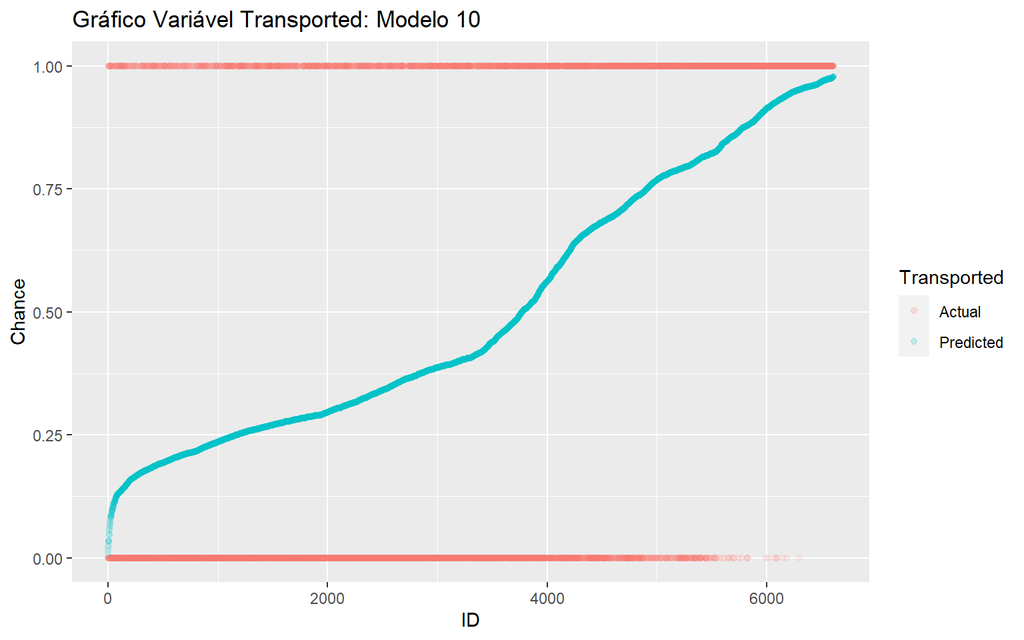

```r
#Transformando a variável resposta como numerica 0 e 1
ds1_train1_final$Transported_f <- as.numeric(ds1_train1_final$Transported_) - 1

ds1_train1_final_order <- ds1_train1_final[order(ds1_train1_final$model10_pred),]
ds1_train1_final_order$ID <- c(1:nrow(ds1_train1_final))

ggplot(data=ds1_train1_final_order, aes(x=ID)) +
  geom_point(aes(y = Transported_f, color = "Actual"), alpha = 0.1) +
  geom_point(aes(y = model10_pred, color = "Predicted"), alpha = 0.1) +
  labs(color='Transported') +
  ggtitle("Gráfico Variável Transported: Modelo 10") +
  ylab("Chance") +
  xlab("ID")
```

```r
#define object to plot and calculate AUC
rocobj_m10 <- roc(ds1_train1_final$Transported_, m10_prob)
auc_10 <- round(auc(ds1_train1_final$Transported_, m10_prob),4)

#plot(rocobj_m10, print.thres=TRUE)
rocobj_m10_optimal <- coords(rocobj_m10, "best", ret = "all", transpose = FALSE)

rocobj_m10_optimal %>%
  kbl %>% kable_paper("hover", full_width = F)
```

|  | threshold | specificity | sensitivity | accuracy | tn | tp | fn | fp | npv | ppv | fdr | fpr | tpr | tnr | fnr | 1-specificity | 1-sensitivity | 1-accuracy | 1-npv | 1-ppv | precision | recall | youden | closest.topleft |
| --- | --- | --- | --- | --- | --- | --- | --- | --- | --- | --- | --- | --- | --- | --- | --- | --- | --- | --- | --- | --- | --- | --- | --- | --- |
| threshold | 0.5563048 | 0.8374504 | 0.6296964 | 0.7328186 | 2746 | 2095 | 1232 | 533 | 0.6902966 | 0.7971842 | 0.2028158 | 0.1625496 | 0.6296964 | 0.8374504 | 0.3703036 | 0.1625496 | 0.3703036 | 0.2671814 | 0.3097034 | 0.2028158 | 0.7971842 | 0.6296964 | 1.467147 | 0.1635471 |

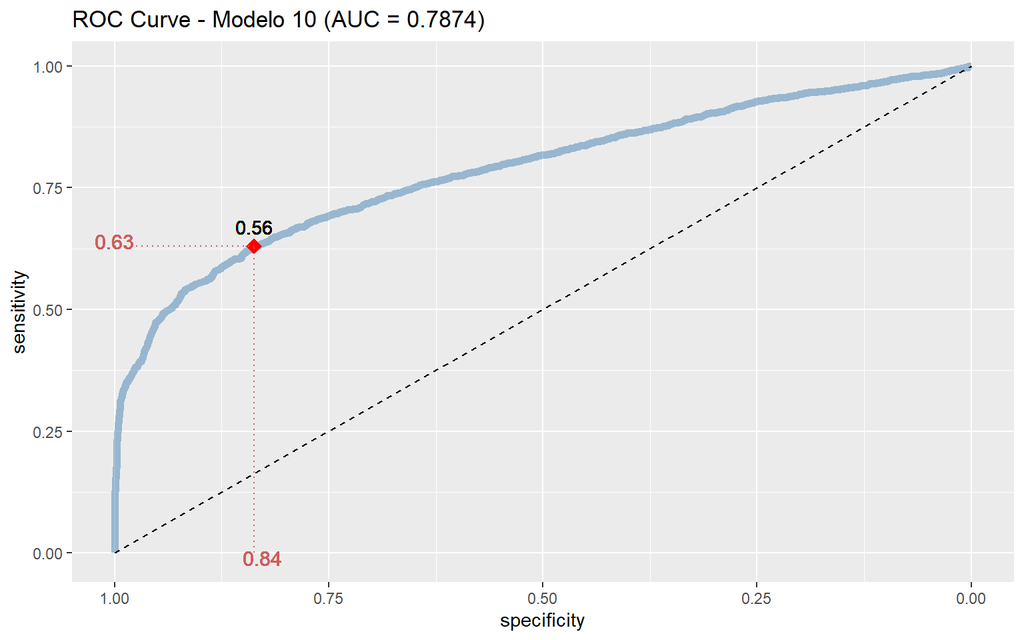

```r
#create ROC plot
ggroc(rocobj_m10, colour = 'steelblue', size = 2 , alpha = 0.5, legacy.axes = FALSE) +
  geom_segment(aes(x = 1, xend = 0, y = 0, yend = 1), color="black", linetype="dashed") +
  geom_point( aes(x = rocobj_m10_optimal$specificity,
                  y = rocobj_m10_optimal$sensitivity),
              color="red", size = 4, pch = 18) +
  geom_segment(aes(x = 1, xend = rocobj_m10_optimal$specificity,
                   y=rocobj_m10_optimal$sensitivity, yend=rocobj_m10_optimal$sensitivity),
               color="indianred", linetype="dotted")+
  geom_segment(aes(x=rocobj_m10_optimal$specificity, xend=rocobj_m10_optimal$specificity,
                   y = 0, yend = rocobj_m10_optimal$sensitivity),
               color="indianred", linetype="dotted") +
  geom_text(aes(x = rocobj_m10_optimal$specificity,
                y = rocobj_m10_optimal$sensitivity),
            label = round(rocobj_m10_optimal$threshold,2),
            nudge_x = 0, nudge_y = 0.04) +
  geom_text(aes(x = 1,
                y = rocobj_m10_optimal$sensitivity),
            color = "indianred", size = 4,
            label = round(rocobj_m10_optimal$sensitivity,2),
            nudge_x = 0, nudge_y = 0.01) +
  geom_text(aes(x = rocobj_m10_optimal$specificity,
                y = 0),
            color = "indianred", size = 4,
            label = round(rocobj_m10_optimal$specificity,2),
            nudge_x = 0.01, nudge_y = -0.01) +
  ggtitle(paste0('ROC Curve - Modelo 10 ', '(AUC = ', auc_10, ')'))
```

### Modelo StepWise

Abaixo plotamos o gráfico da variável resposta original versus sua predição.

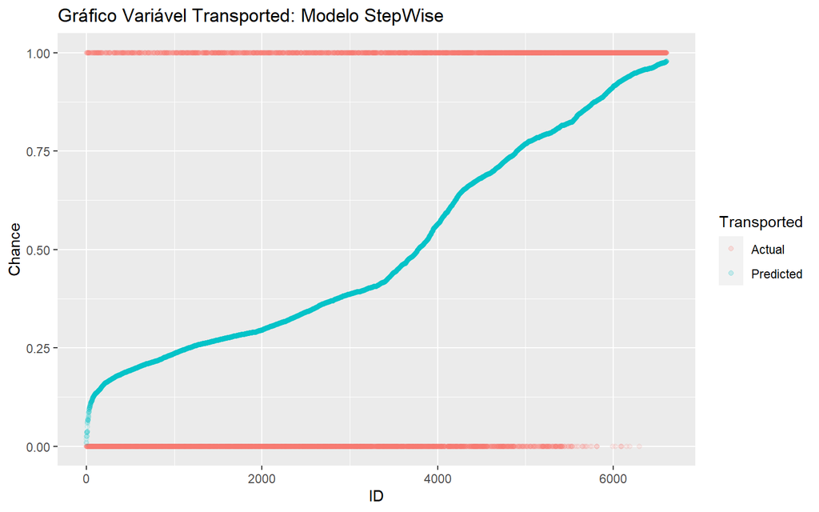

```r
ds1_train1_final_order2 <- ds1_train1_final[order(ds1_train1_final$modelstep_pred),]
ds1_train1_final_order2$ID <- c(1:nrow(ds1_train1_final))

ggplot(data=ds1_train1_final_order2, aes(x=ID)) +
  geom_point(aes(y = Transported_f, color = "Actual"), alpha = 0.1) +
  geom_point(aes(y = modelstep_pred, color = "Predicted"), alpha = 0.1) +
  labs(color='Transported') +
  ggtitle("Gráfico Variável Transported: Modelo StepWise") +
  ylab("Chance") +
  xlab("ID")
```

```r
#define object to plot and calculate AUC
rocobj_mstep <- roc(ds1_train1_final$Transported_, m10_prob)
auc_step <- round(auc(ds1_train1_final$Transported_, m10_prob),4)

#plot(rocobj_mstep, print.thres=TRUE)
rocobj_mstep_optimal <- coords(rocobj_mstep, "best", ret = "all", transpose = FALSE)

rocobj_mstep_optimal %>%
  kbl %>% kable_paper("hover", full_width = F)
```

|  | threshold | specificity | sensitivity | accuracy | tn | tp | fn | fp | npv | ppv | fdr | fpr | tpr | tnr | fnr | 1-specificity | 1-sensitivity | 1-accuracy | 1-npv | 1-ppv | precision | recall | youden | closest.topleft |
| --- | --- | --- | --- | --- | --- | --- | --- | --- | --- | --- | --- | --- | --- | --- | --- | --- | --- | --- | --- | --- | --- | --- | --- | --- |
| threshold | 0.5563048 | 0.8374504 | 0.6296964 | 0.7328186 | 2746 | 2095 | 1232 | 533 | 0.6902966 | 0.7971842 | 0.2028158 | 0.1625496 | 0.6296964 | 0.8374504 | 0.3703036 | 0.1625496 | 0.3703036 | 0.2671814 | 0.3097034 | 0.2028158 | 0.7971842 | 0.6296964 | 1.467147 | 0.1635471 |

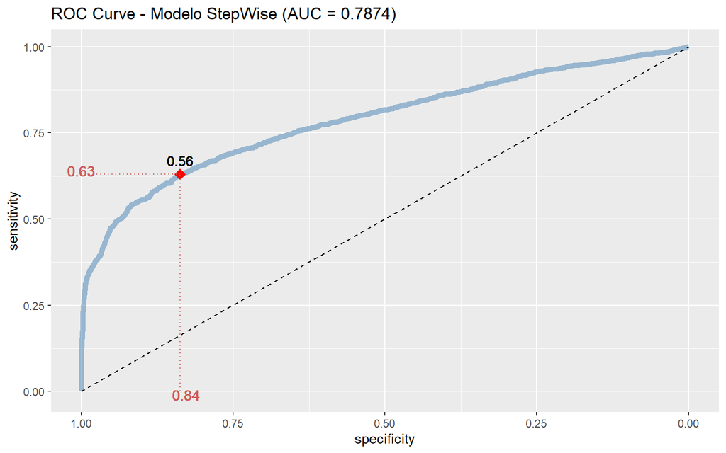

```r
#create ROC plot
ggroc(rocobj_mstep, colour = 'steelblue', size = 2 , alpha = 0.5, legacy.axes = FALSE) +
  geom_segment(aes(x = 1, xend = 0, y = 0, yend = 1), color="black", linetype="dashed") +
  geom_point( aes(x = rocobj_mstep_optimal$specificity,
                  y = rocobj_mstep_optimal$sensitivity),
              color="red", size = 4, pch = 18) +
  geom_segment(aes(x = 1, xend = rocobj_mstep_optimal$specificity,
                   y=rocobj_mstep_optimal$sensitivity, yend=rocobj_mstep_optimal$sensitivity),
               color="indianred", linetype="dotted")+
  geom_segment(aes(x=rocobj_mstep_optimal$specificity, xend=rocobj_mstep_optimal$specificity,
                   y = 0, yend = rocobj_mstep_optimal$sensitivity),
               color="indianred", linetype="dotted") +
  geom_text(aes(x = rocobj_mstep_optimal$specificity,
                y = rocobj_mstep_optimal$sensitivity),
            label = round(rocobj_mstep_optimal$threshold,2),
            nudge_x = 0, nudge_y = 0.04) +
  geom_text(aes(x = 1,
                y = rocobj_mstep_optimal$sensitivity),
            color = "indianred", size = 4,
            label = round(rocobj_mstep_optimal$sensitivity,2),
            nudge_x = 0, nudge_y = 0.01) +
  geom_text(aes(x = rocobj_mstep_optimal$specificity,
                y = 0),
            color = "indianred", size = 4,
            label = round(rocobj_mstep_optimal$specificity,2),
            nudge_x = 0.01, nudge_y = -0.01) +
  ggtitle(paste0('ROC Curve - Modelo StepWise ', '(AUC = ', auc_step, ')'))
```

```r
#removido do trabalho
# Compute AUC metrics for cv_model3 and cv_model2
perf1 <- prediction(m10_prob, ds1_train1_final$Transported_) %>%
  performance(measure = "tpr", x.measure = "fpr")
perf2 <- prediction(mstep_prob, ds1_train1_final$Transported_) %>%
  performance(measure = "tpr", x.measure = "fpr")

# Plot ROC curves for cv_model3 and cv_model2
plot(perf1, col = "red", lty = 2, lwd = 0.5, type="l", pch=1,
     print.cutoffs.at = seq(from = 1, to = 0, by = -0.1)
     )
#plot(perf2, add = TRUE, col = "blue", lty = 2, lwd = 0.5, type="l", pch=1)
legend(0.8, 0.2, legend = c("Modelo 10", "Modelo StepWise"),
       col = c("red", "blue"), lty = c(2,2), lwd = 1, cex = 0.6)
```

```r
ds1_train1_final$model10_pred.f <- ifelse(ds1_train1_final$model10_pred >= rocobj_m10_optimal$threshold, 1, 0)
ds1_train1_final$modelstep_pred.f <- ifelse(ds1_train1_final$modelstep_pred >= rocobj_mstep_optimal$threshold, 1, 0)
```

Concluimos então a avaliação do modelo. O melhor modelo é o Modelo 10 pois pela parcimonia, a variável **VIP** estão ou não no modelo não faz diferença quando comparamos o AIC. Descobrimos o ponto ótimo de corte que dos dá uma acurácia de 73 % utilizando o ponto de corte de 0.56 .

# Aplicação [Deployment]

Vamos então para a parte mais esperada, fazer a predição da base **Test**.  
Utilizo o Modelo 10 para fazer a predição:

```r
# Compute predicted probabilities
m10_prob <- predict(cv_model3, ds1_test1_final, type = "prob")$"1"
#mstep_prob <- predict(cv_model2, ds1_test1_final, type = "prob")$"1"

ds1_test1_final$model10_pred <- m10_prob
#ds1_test1_final$modelstep_pred <- mstep_prob
```

Faço o gráfico mostrando a variável predita com a variável resposta que neste caso veio do arquivo sample_submission, mostrando que todos os valores eram falsos.

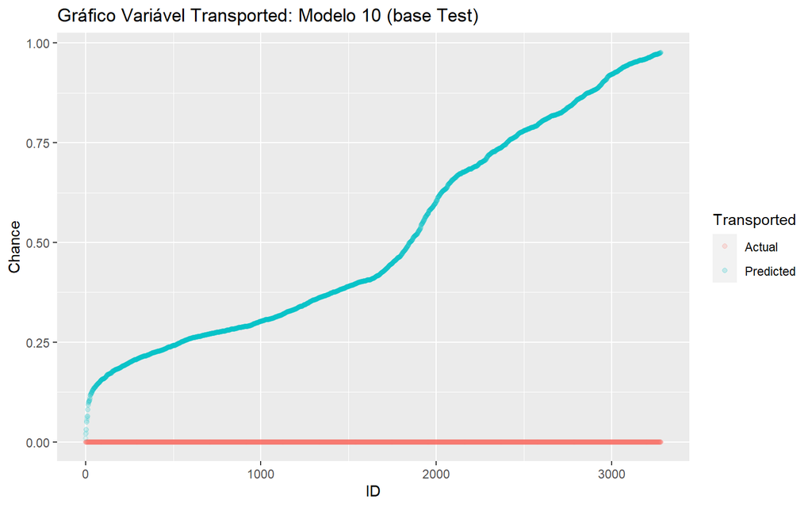

```r
#Transformando a variável resposta como numerica 0 e 1
ds1_test1_final$Transported_f <- as.numeric(ds1_test1_final$Transported_) - 1

ds1_test1_final_order <- ds1_test1_final[order(ds1_test1_final$model10_pred),]
ds1_test1_final_order$ID <- c(1:nrow(ds1_test1_final))

ggplot(data=ds1_test1_final_order, aes(x=ID)) +
  geom_point(aes(y = Transported_f, color = "Actual"), alpha = 0.1) +
  geom_point(aes(y = model10_pred, color = "Predicted"), alpha = 0.1) +
  labs(color='Transported') +
  ggtitle("Gráfico Variável Transported: Modelo 10 (base Test)") +
  ylab("Chance") +
  xlab("ID")
```

Vamos usar o ponto de ótimo de corte para criar a variável predita final, já que é nesse formato que temos que eviar o arquivo.

```r
ds1_test1_final$model10_pred.f <- ifelse(ds1_test1_final$model10_pred >=
                                           rocobj_m10_optimal$threshold, 1, 0)
ds1_test1_final$model10_pred.f2 <- ifelse(ds1_test1_final$model10_pred >=
                                           rocobj_m10_optimal$threshold, "TRUE", "FALSE")
```

```r
ds1_test1_final_submission <- cbind(paste0(ds1_test1_final$GroupID,
                                           "_",
                                           ds1_test1_final$QtyID),
                                    ds1_test1_final$model10_pred.f2)

colnames(ds1_test1_final_submission) <- c("PassengerID", "Transported_Prediction")

head(ds1_test1_final_submission) %>%
  kbl %>% kable_paper(c("striped", "hover"), full_width = F, fixed_thead = T)
```

| PassengerID | Transported_Prediction |
| --- | --- |
| 0013_01 | TRUE |
| 0018_01 | FALSE |
| 0019_01 | TRUE |
| 0021_01 | FALSE |
| 0023_01 | FALSE |
| 0027_01 | FALSE |

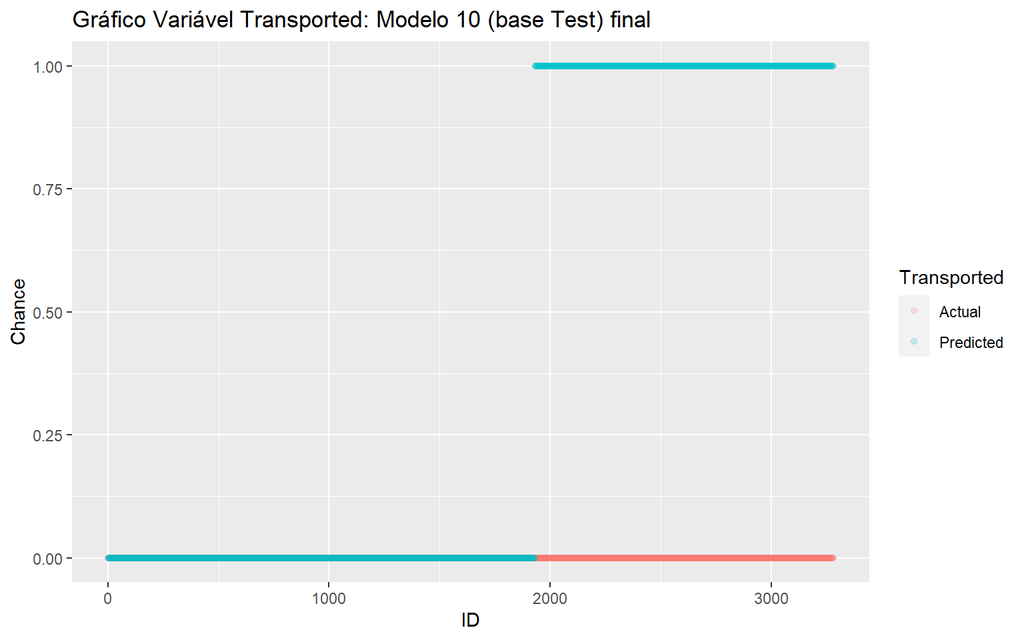

```r
ds1_test1_final_order1 <- ds1_test1_final[order(ds1_test1_final$model10_pred),]
ds1_test1_final_order1$ID <- c(1:nrow(ds1_test1_final))

ggplot(data=ds1_test1_final_order1, aes(x=ID)) +
  geom_point(aes(y = Transported_f, color = "Actual"), alpha = 0.1) +
  geom_point(aes(y = model10_pred.f, color = "Predicted"), alpha = 0.1) +
  labs(color='Transported') +
  ggtitle("Gráfico Variável Transported: Modelo 10 (base Test) final") +
  ylab("Chance") +
  xlab("ID")
```

## Exportando o arquivo final

```r
write.csv(ds1_test1_final_submission,".\\final_submission.csv", row.names = FALSE)
```